# Predict Bike Sharing Demand with AutoGluon Template

## Project: Predict Bike Sharing Demand with AutoGluon

This notebook is a template with each step that you need to complete for the project.

Please fill in your code where there are explicit `?` markers in the notebook. You are welcome to add more cells and code as you see fit.

Once you have completed all the code implementations, please export your notebook as a HTML file so the reviews can view your code. Make sure you have all outputs correctly outputted.

`File-> Export Notebook As... -> Export Notebook as HTML`

There is a writeup to complete as well after all code implememtation is done. Please answer all questions and attach the necessary tables and charts. You can complete the writeup in either markdown or PDF.

Completing the code template and writeup template will cover all of the rubric points for this project.

The rubric contains "Stand Out Suggestions" for enhancing the project beyond the minimum requirements. The stand out suggestions are optional. If you decide to pursue the "stand out suggestions", you can include the code in this notebook and also discuss the results in the writeup file.

## Step 1: Create an account with Kaggle

### Create Kaggle Account and download API key

Below is example of steps to get the API username and key. Each student will have their own username and key.

1. Open account settings.

2. Scroll down to API and click Create New API Token.

3. Open up `kaggle.json` and use the username and key.


## Step 2: Download the Kaggle dataset using the kaggle python library

### Open up Sagemaker Studio and use starter template

1. Notebook should be using a `ml.t3.medium` instance (2 vCPU + 4 GiB)
2. Notebook should be using kernal: `Python 3 (MXNet 1.8 Python 3.7 CPU Optimized)`

# ↓ ↓ ↓ ↓ ↓ ↓ ↓ ↓ ↓ ↓ ↓ ↓ ↓ ↓ ↓ ↓ ↓

I did not run this code because the whole project was implemented on a home computer with:  
`Windows10 + Cnaconda + Virtual Environment`.  
All required packages were installed before starting the project

### Install packages

```python
# !pip install -U pip
# !pip install -U setuptools wheel
# !pip install -U "mxnet<2.0.0" bokeh==2.0.1
# !pip install autogluon --no-cache-dir
# # Without --no-cache-dir, smaller aws instances may have trouble installing
```

### Setup Kaggle API Key

```python
# create the .kaggle directory and an empty kaggle.json file
# !mkdir -p /root/.kaggle
# !touch /root/.kaggle/kaggle.json
# !chmod 600 /root/.kaggle/kaggle.json
```

```python
# Fill in your user name and key from creating the kaggle account and API token file
# import json
# kaggle_username = "FILL_IN_USERNAME"
# kaggle_key = "FILL_IN_KEY"

# # Save API token the kaggle.json file
# with open("/root/.kaggle/kaggle.json", "w") as f:
#     f.write(json.dumps({"username": kaggle_username, "key": kaggle_key}))
```

### Download and explore dataset

### Go to the bike sharing demand competition and agree to the terms

```python
# # Download the dataset, it will be in a .zip file so you'll need to unzip it as well.
# !kaggle competitions download -c bike-sharing-demand
# # If you already downloaded it you can use the -o command to overwrite the file
# !unzip -o bike-sharing-demand.zip
```

I did not run this code because the whole project was implemented on a home computer with:  
`Windows10 + Cnaconda + Virtual Environment`.  
All required packages were installed before starting the project.

# ↑ ↑ ↑ ↑ ↑ ↑ ↑ ↑ ↑ ↑ ↑ ↑ ↑ ↑ ↑ ↑ ↑

```python
import pandas as pd
from autogluon.tabular import TabularPredictor
```

```python
# Create the train dataset in pandas by reading the csv
# Set the parsing of the datetime column so you can use some of the `dt` features in pandas later
train = pd.read_csv("train.csv",parse_dates=["datetime"])
train.head()
```

|  | datetime | season | holiday | workingday | weather | temp | atemp | humidity | windspeed | casual | registered | count |
| --- | --- | --- | --- | --- | --- | --- | --- | --- | --- | --- | --- | --- |
| 0 | 2011-01-01 00:00:00 | 1 | 0 | 0 | 1 | 9.84 | 14.395 | 81 | 0.0 | 3 | 13 | 16 |
| 1 | 2011-01-01 01:00:00 | 1 | 0 | 0 | 1 | 9.02 | 13.635 | 80 | 0.0 | 8 | 32 | 40 |
| 2 | 2011-01-01 02:00:00 | 1 | 0 | 0 | 1 | 9.02 | 13.635 | 80 | 0.0 | 5 | 27 | 32 |
| 3 | 2011-01-01 03:00:00 | 1 | 0 | 0 | 1 | 9.84 | 14.395 | 75 | 0.0 | 3 | 10 | 13 |
| 4 | 2011-01-01 04:00:00 | 1 | 0 | 0 | 1 | 9.84 | 14.395 | 75 | 0.0 | 0 | 1 | 1 |

```python
# View column types
print('Number of samples in the "train" dataset:',len(train),'\n')
train.info()
```

```
Number of samples in the "train" dataset: 10886

<class 'pandas.core.frame.DataFrame'>
RangeIndex: 10886 entries, 0 to 10885
Data columns (total 12 columns):
 #   Column      Non-Null Count  Dtype
---  ------      --------------  -----
 0   datetime    10886 non-null  datetime64[ns]
 1   season      10886 non-null  int64
 2   holiday     10886 non-null  int64
 3   workingday  10886 non-null  int64
 4   weather     10886 non-null  int64
 5   temp        10886 non-null  float64
 6   atemp       10886 non-null  float64
 7   humidity    10886 non-null  int64
 8   windspeed   10886 non-null  float64
 9   casual      10886 non-null  int64
 10  registered  10886 non-null  int64
 11  count       10886 non-null  int64
dtypes: datetime64[ns](1), float64(3), int64(8)
memory usage: 1020.7 KB
```

IMPORTANT: No missing values

```python
# View min/max/varition of the dataset features.
train.describe()
```

|  | season | holiday | workingday | weather | temp | atemp | humidity | windspeed | casual | registered | count |
| --- | --- | --- | --- | --- | --- | --- | --- | --- | --- | --- | --- |
| count | 10886.000000 | 10886.000000 | 10886.000000 | 10886.000000 | 10886.00000 | 10886.000000 | 10886.000000 | 10886.000000 | 10886.000000 | 10886.000000 | 10886.000000 |
| mean | 2.506614 | 0.028569 | 0.680875 | 1.418427 | 20.23086 | 23.655084 | 61.886460 | 12.799395 | 36.021955 | 155.552177 | 191.574132 |
| std | 1.116174 | 0.166599 | 0.466159 | 0.633839 | 7.79159 | 8.474601 | 19.245033 | 8.164537 | 49.960477 | 151.039033 | 181.144454 |
| min | 1.000000 | 0.000000 | 0.000000 | 1.000000 | 0.82000 | 0.760000 | 0.000000 | 0.000000 | 0.000000 | 0.000000 | 1.000000 |
| 25% | 2.000000 | 0.000000 | 0.000000 | 1.000000 | 13.94000 | 16.665000 | 47.000000 | 7.001500 | 4.000000 | 36.000000 | 42.000000 |
| 50% | 3.000000 | 0.000000 | 1.000000 | 1.000000 | 20.50000 | 24.240000 | 62.000000 | 12.998000 | 17.000000 | 118.000000 | 145.000000 |
| 75% | 4.000000 | 0.000000 | 1.000000 | 2.000000 | 26.24000 | 31.060000 | 77.000000 | 16.997900 | 49.000000 | 222.000000 | 284.000000 |
| max | 4.000000 | 1.000000 | 1.000000 | 4.000000 | 41.00000 | 45.455000 | 100.000000 | 56.996900 | 367.000000 | 886.000000 | 977.000000 |

```python
# Create the test pandas dataframe in pandas by reading the csv, remember to parse the datetime!
test = pd.read_csv("test.csv",parse_dates=["datetime"])
test.head()
```

|  | datetime | season | holiday | workingday | weather | temp | atemp | humidity | windspeed |
| --- | --- | --- | --- | --- | --- | --- | --- | --- | --- |
| 0 | 2011-01-20 00:00:00 | 1 | 0 | 1 | 1 | 10.66 | 11.365 | 56 | 26.0027 |
| 1 | 2011-01-20 01:00:00 | 1 | 0 | 1 | 1 | 10.66 | 13.635 | 56 | 0.0000 |
| 2 | 2011-01-20 02:00:00 | 1 | 0 | 1 | 1 | 10.66 | 13.635 | 56 | 0.0000 |
| 3 | 2011-01-20 03:00:00 | 1 | 0 | 1 | 1 | 10.66 | 12.880 | 56 | 11.0014 |
| 4 | 2011-01-20 04:00:00 | 1 | 0 | 1 | 1 | 10.66 | 12.880 | 56 | 11.0014 |

```python
# View column types
print('Number of samples in the "test" dataset:',len(test),'\n')
test.info()
```

```
Number of samples in the "test" dataset: 6493

<class 'pandas.core.frame.DataFrame'>
RangeIndex: 6493 entries, 0 to 6492
Data columns (total 9 columns):
 #   Column      Non-Null Count  Dtype
---  ------      --------------  -----
 0   datetime    6493 non-null   datetime64[ns]
 1   season      6493 non-null   int64
 2   holiday     6493 non-null   int64
 3   workingday  6493 non-null   int64
 4   weather     6493 non-null   int64
 5   temp        6493 non-null   float64
 6   atemp       6493 non-null   float64
 7   humidity    6493 non-null   int64
 8   windspeed   6493 non-null   float64
dtypes: datetime64[ns](1), float64(3), int64(5)
memory usage: 456.7 KB
```

IMPORTANT: No missing values

```python
test.describe()
```

|  | season | holiday | workingday | weather | temp | atemp | humidity | windspeed |
| --- | --- | --- | --- | --- | --- | --- | --- | --- |
| count | 6493.000000 | 6493.000000 | 6493.000000 | 6493.000000 | 6493.000000 | 6493.000000 | 6493.000000 | 6493.000000 |
| mean | 2.493300 | 0.029108 | 0.685815 | 1.436778 | 20.620607 | 24.012865 | 64.125212 | 12.631157 |
| std | 1.091258 | 0.168123 | 0.464226 | 0.648390 | 8.059583 | 8.782741 | 19.293391 | 8.250151 |
| min | 1.000000 | 0.000000 | 0.000000 | 1.000000 | 0.820000 | 0.000000 | 16.000000 | 0.000000 |
| 25% | 2.000000 | 0.000000 | 0.000000 | 1.000000 | 13.940000 | 16.665000 | 49.000000 | 7.001500 |
| 50% | 3.000000 | 0.000000 | 1.000000 | 1.000000 | 21.320000 | 25.000000 | 65.000000 | 11.001400 |
| 75% | 3.000000 | 0.000000 | 1.000000 | 2.000000 | 27.060000 | 31.060000 | 81.000000 | 16.997900 |
| max | 4.000000 | 1.000000 | 1.000000 | 4.000000 | 40.180000 | 50.000000 | 100.000000 | 55.998600 |

```python
#Comparison of attribute lists in the training and test sets
train_columns = list(train.columns)
test_columns = list(test.columns)

print('Training set variables:\n',train_columns)
print('\nTest set variables:\n',test_columns)
print('\nTraining set variables that are absent in test set:\n',[col for col in train_columns if col not in test_columns])
```

```
Training set variables:
 ['datetime', 'season', 'holiday', 'workingday', 'weather', 'temp', 'atemp', 'humidity', 'windspeed', 'casual', 'registered', 'count']

Test set variables:
 ['datetime', 'season', 'holiday', 'workingday', 'weather', 'temp', 'atemp', 'humidity', 'windspeed']

Training set variables that are absent in test set:
 ['casual', 'registered', 'count']
```

```python
# Same thing as train and test dataset
submission = pd.read_csv("sampleSubmission.csv",parse_dates=["datetime"])
print('Number of samples in the "submission" dataset:',len(submission),'\n')
submission.head()
```

```
Number of samples in the "submission" dataset: 6493
```

|  | datetime | count |
| --- | --- | --- |
| 0 | 2011-01-20 00:00:00 | 0 |
| 1 | 2011-01-20 01:00:00 | 0 |
| 2 | 2011-01-20 02:00:00 | 0 |
| 3 | 2011-01-20 03:00:00 | 0 |
| 4 | 2011-01-20 04:00:00 | 0 |

## Step 3: Train a model using AutoGluon’s Tabular Prediction

Requirements:

- We are prediting `count`, so it is the label we are setting.
- Ignore `casual` and `registered` columns as they are also not present in the test dataset.
- Use the `root_mean_squared_error` as the metric to use for evaluation.
- Set a time limit of 10 minutes (600 seconds).
- Use the preset `best_quality` to focus on creating the best model.

```python
predictor = TabularPredictor(label="count", problem_type='regression', eval_metric="root_mean_squared_error",
learner_kwargs={"ignored_columns": ["casual", "registered"]}).fit(train_data=train,
time_limit=600,
presets="best_quality")
```

```
No path specified. Models will be saved in: "AutogluonModels\ag-20230528_080539\"
Presets specified: ['best_quality']
Stack configuration (auto_stack=True): num_stack_levels=1, num_bag_folds=8, num_bag_sets=20
Beginning AutoGluon training ... Time limit = 600s
AutoGluon will save models to "AutogluonModels\ag-20230528_080539\"
AutoGluon Version:  0.6.2
Python Version:     3.7.16
Operating System:   Windows
Platform Machine:   AMD64
Platform Version:   10.0.19041
Train Data Rows:    10886
Train Data Columns: 11
Label Column: count
Preprocessing data ...
Using Feature Generators to preprocess the data ...
Dropping user-specified ignored columns: ['casual', 'registered']
Fitting AutoMLPipelineFeatureGenerator...
	Available Memory:                    9296.27 MB
	Train Data (Original)  Memory Usage: 0.78 MB (0.0% of available memory)
	Inferring data type of each feature based on column values. Set feature_metadata_in to manually specify special dtypes of the features.
	Stage 1 Generators:
		Fitting AsTypeFeatureGenerator...
			Note: Converting 2 features to boolean dtype as they only contain 2 unique values.
	Stage 2 Generators:
		Fitting FillNaFeatureGenerator...
	Stage 3 Generators:
		Fitting IdentityFeatureGenerator...
		Fitting DatetimeFeatureGenerator...
	Stage 4 Generators:
		Fitting DropUniqueFeatureGenerator...
	Types of features in original data (raw dtype, special dtypes):
		('datetime', []) : 1 | ['datetime']
		('float', [])    : 3 | ['temp', 'atemp', 'windspeed']
		('int', [])      : 5 | ['season', 'holiday', 'workingday', 'weather', 'humidity']
	Types of features in processed data (raw dtype, special dtypes):
		('float', [])                : 3 | ['temp', 'atemp', 'windspeed']
		('int', [])                  : 3 | ['season', 'weather', 'humidity']
		('int', ['bool'])            : 2 | ['holiday', 'workingday']
		('int', ['datetime_as_int']) : 5 | ['datetime', 'datetime.year', 'datetime.month', 'datetime.day', 'datetime.dayofweek']
	0.2s = Fit runtime
	9 features in original data used to generate 13 features in processed data.
	Train Data (Processed) Memory Usage: 0.98 MB (0.0% of available memory)
Data preprocessing and feature engineering runtime = 0.25s ...
AutoGluon will gauge predictive performance using evaluation metric: 'root_mean_squared_error'
	This metric's sign has been flipped to adhere to being higher_is_better. The metric score can be multiplied by -1 to get the metric value.
	To change this, specify the eval_metric parameter of Predictor()
AutoGluon will fit 2 stack levels (L1 to L2) ...
Fitting 11 L1 models ...
Fitting model: KNeighborsUnif_BAG_L1 ... Training model for up to 399.74s of the 599.75s of remaining time.
	-101.5882	 = Validation score   (-root_mean_squared_error)
	0.06s	 = Training   runtime
	0.12s	 = Validation runtime
Fitting model: KNeighborsDist_BAG_L1 ... Training model for up to 392.68s of the 592.69s of remaining time.
	-84.1464	 = Validation score   (-root_mean_squared_error)
	0.08s	 = Training   runtime
	0.12s	 = Validation runtime
Fitting model: LightGBMXT_BAG_L1 ... Training model for up to 392.26s of the 592.27s of remaining time.
Will use sequential fold fitting strategy because import of ray failed. Reason: ray is required to train folds in parallel. A quick tip is to install via `pip install ray==2.0.0`, or use sequential fold fitting by passing `sequential_local` to `ag_args_ensemble` when calling tabular.fitFor example: …
	Fitting 8 child models (S1F1 - S1F8) | Fitting with SequentialLocalFoldFittingStrategy
```

[output not shown]

```
	-131.4609	 = Validation score   (-root_mean_squared_error)
	32.0s	 = Training   runtime
	1.21s	 = Validation runtime
Fitting model: LightGBM_BAG_L1 ... Training model for up to 353.79s of the 553.8s of remaining time.
	Fitting 8 child models (S1F1 - S1F8) | Fitting with SequentialLocalFoldFittingStrategy
```

```
[1000]	valid_set's rmse: 130.818
[1000]	valid_set's rmse: 133.204
[1000]	valid_set's rmse: 130.928
[1000]	valid_set's rmse: 126.846
[1000]	valid_set's rmse: 131.426
[1000]	valid_set's rmse: 133.655
[1000]	valid_set's rmse: 132.155
[1000]	valid_set's rmse: 130.62
```

```
	-131.0542	 = Validation score   (-root_mean_squared_error)
	9.07s	 = Training   runtime
	0.16s	 = Validation runtime
Fitting model: RandomForestMSE_BAG_L1 ... Training model for up to 342.92s of the 542.93s of remaining time.
	-116.5438	 = Validation score   (-root_mean_squared_error)
	3.27s	 = Training   runtime
	0.52s	 = Validation runtime
Fitting model: CatBoost_BAG_L1 ... Training model for up to 328.29s of the 528.3s of remaining time.
	Fitting 8 child models (S1F1 - S1F8) | Fitting with SequentialLocalFoldFittingStrategy
	Ran out of time, early stopping on iteration 5099.
	Ran out of time, early stopping on iteration 5300.
	Ran out of time, early stopping on iteration 5478.
	Ran out of time, early stopping on iteration 5769.
	-130.4886	 = Validation score   (-root_mean_squared_error)
	240.89s	 = Training   runtime
	0.05s	 = Validation runtime
Fitting model: ExtraTreesMSE_BAG_L1 ... Training model for up to 85.93s of the 285.94s of remaining time.
	-124.594	 = Validation score   (-root_mean_squared_error)
	1.58s	 = Training   runtime
	0.47s	 = Validation runtime
Fitting model: NeuralNetFastAI_BAG_L1 ... Training model for up to 72.52s of the 272.54s of remaining time.
	Fitting 8 child models (S1F1 - S1F8) | Fitting with SequentialLocalFoldFittingStrategy
	Warning: Exception caused NeuralNetFastAI_BAG_L1 to fail during training (ImportError)... Skipping this model.
		Import fastai failed. A quick tip is to install via `pip install autogluon.tabular[fastai]==0.6.2`.
Fitting model: XGBoost_BAG_L1 ... Training model for up to 72.45s of the 272.47s of remaining time.
	Fitting 8 child models (S1F1 - S1F8) | Fitting with SequentialLocalFoldFittingStrategy
	-131.6247	 = Validation score   (-root_mean_squared_error)
	7.2s	 = Training   runtime
	0.15s	 = Validation runtime
Fitting model: NeuralNetTorch_BAG_L1 ... Training model for up to 64.06s of the 264.07s of remaining time.
	Fitting 8 child models (S1F1 - S1F8) | Fitting with SequentialLocalFoldFittingStrategy
	Not enough time to train first epoch. (Time Required: 83.77s, Time Left: 6.28s)
	Time limit exceeded... Skipping NeuralNetTorch_BAG_L1.
Fitting model: LightGBMLarge_BAG_L1 ... Training model for up to 63.79s of the 263.8s of remaining time.
	Fitting 8 child models (S1F1 - S1F8) | Fitting with SequentialLocalFoldFittingStrategy
	-130.1323	 = Validation score   (-root_mean_squared_error)
	14.39s	 = Training   runtime
	0.15s	 = Validation runtime
Completed 1/20 k-fold bagging repeats ...
Fitting model: WeightedEnsemble_L2 ... Training model for up to 360.0s of the 246.56s of remaining time.
	-84.1464	 = Validation score   (-root_mean_squared_error)
	0.37s	 = Training   runtime
	0.0s	 = Validation runtime
Fitting 9 L2 models ...
Fitting model: LightGBMXT_BAG_L2 ... Training model for up to 246.15s of the 246.14s of remaining time.
	Fitting 8 child models (S1F1 - S1F8) | Fitting with SequentialLocalFoldFittingStrategy
```

[output not shown]

```
	-60.1487	 = Validation score   (-root_mean_squared_error)
	23.85s	 = Training   runtime
	0.43s	 = Validation runtime
Fitting model: LightGBM_BAG_L2 ... Training model for up to 218.79s of the 218.78s of remaining time.
	Fitting 8 child models (S1F1 - S1F8) | Fitting with SequentialLocalFoldFittingStrategy
	-54.9885	 = Validation score   (-root_mean_squared_error)
	6.31s	 = Training   runtime
	0.08s	 = Validation runtime
Fitting model: RandomForestMSE_BAG_L2 ... Training model for up to 211.98s of the 211.97s of remaining time.
	-53.385	 = Validation score   (-root_mean_squared_error)
	6.26s	 = Training   runtime
	0.56s	 = Validation runtime
Fitting model: CatBoost_BAG_L2 ... Training model for up to 194.05s of the 194.04s of remaining time.
	Fitting 8 child models (S1F1 - S1F8) | Fitting with SequentialLocalFoldFittingStrategy
	-55.7782	 = Validation score   (-root_mean_squared_error)
	65.16s	 = Training   runtime
	0.04s	 = Validation runtime
Fitting model: ExtraTreesMSE_BAG_L2 ... Training model for up to 128.25s of the 128.24s of remaining time.
	-53.6955	 = Validation score   (-root_mean_squared_error)
	2.32s	 = Training   runtime
	0.59s	 = Validation runtime
Fitting model: NeuralNetFastAI_BAG_L2 ... Training model for up to 114.45s of the 114.44s of remaining time.
	Fitting 8 child models (S1F1 - S1F8) | Fitting with SequentialLocalFoldFittingStrategy
	Warning: Exception caused NeuralNetFastAI_BAG_L2 to fail during training (ImportError)... Skipping this model.
		Import fastai failed. A quick tip is to install via `pip install autogluon.tabular[fastai]==0.6.2`.
Fitting model: XGBoost_BAG_L2 ... Training model for up to 114.37s of the 114.36s of remaining time.
	Fitting 8 child models (S1F1 - S1F8) | Fitting with SequentialLocalFoldFittingStrategy
	-54.8329	 = Validation score   (-root_mean_squared_error)
	9.4s	 = Training   runtime
	0.09s	 = Validation runtime
Fitting model: NeuralNetTorch_BAG_L2 ... Training model for up to 104.17s of the 104.15s of remaining time.
	Fitting 8 child models (S1F1 - S1F8) | Fitting with SequentialLocalFoldFittingStrategy
	Not enough time to train first epoch. (Time Required: 110.43s, Time Left: 10.31s)
	Time limit exceeded... Skipping NeuralNetTorch_BAG_L2.
Fitting model: LightGBMLarge_BAG_L2 ... Training model for up to 103.88s of the 103.87s of remaining time.
	Fitting 8 child models (S1F1 - S1F8) | Fitting with SequentialLocalFoldFittingStrategy
	-54.9733	 = Validation score   (-root_mean_squared_error)
	16.89s	 = Training   runtime
	0.09s	 = Validation runtime
Completed 1/20 k-fold bagging repeats ...
Fitting model: WeightedEnsemble_L3 ... Training model for up to 360.0s of the 85.62s of remaining time.
	-52.7224	 = Validation score   (-root_mean_squared_error)
	0.33s	 = Training   runtime
	0.0s	 = Validation runtime
AutoGluon training complete, total runtime = 514.8s ... Best model: "WeightedEnsemble_L3"
TabularPredictor saved. To load, use: predictor = TabularPredictor.load("AutogluonModels\ag-20230528_080539\")
```

### Review AutoGluon's training run with ranking of models that did the best.

```python
predictor.fit_summary()
```

```
*** Summary of fit() ***
Estimated performance of each model:
                     model   score_val  pred_time_val    fit_time  pred_time_val_marginal  fit_time_marginal  stack_level  can_infer  fit_order
0      WeightedEnsemble_L3  -52.722403       4.274575  333.168857                0.000996           0.331204            3       True         18
1   RandomForestMSE_BAG_L2  -53.384970       3.519012  314.809569                0.562768           6.259594            2       True         13
2     ExtraTreesMSE_BAG_L2  -53.695548       3.546910  310.869328                0.590666           2.319353            2       True         15
3           XGBoost_BAG_L2  -54.832911       3.042195  317.949351                0.085951           9.399376            2       True         16
4     LightGBMLarge_BAG_L2  -54.973272       3.045701  325.440275                0.089456          16.890300            2       True         17
5          LightGBM_BAG_L2  -54.988473       3.034195  314.859330                0.077951           6.309355            2       True         12
6          CatBoost_BAG_L2  -55.778191       2.995219  373.711238                0.038975          65.161263            2       True         14
7        LightGBMXT_BAG_L2  -60.148696       3.383007  332.397513                0.426762          23.847538            2       True         11
8    KNeighborsDist_BAG_L1  -84.146423       0.117946    0.081943                0.117946           0.081943            1       True          2
9      WeightedEnsemble_L2  -84.146423       0.118945    0.456722                0.001000           0.374779            2       True         10
10   KNeighborsUnif_BAG_L1 -101.588176       0.119940    0.058464                0.119940           0.058464            1       True          1
11  RandomForestMSE_BAG_L1 -116.543822       0.520367    3.273318                0.520367           3.273318            1       True          5
12    ExtraTreesMSE_BAG_L1 -124.594043       0.473746    1.577186                0.473746           1.577186            1       True          7
13    LightGBMLarge_BAG_L1 -130.132290       0.154913   14.394892                0.154913          14.394892            1       True          9
14         CatBoost_BAG_L1 -130.488586       0.048928  240.891248                0.048928         240.891248            1       True          6
15         LightGBM_BAG_L1 -131.054162       0.158610    9.071611                0.158610           9.071611            1       True          4
16       LightGBMXT_BAG_L1 -131.460909       1.214884   32.003636                1.214884          32.003636            1       True          3
17          XGBoost_BAG_L1 -131.624665       0.146910    7.197678                0.146910           7.197678            1       True          8
Number of models trained: 18
Types of models trained:
{'WeightedEnsembleModel', 'StackerEnsembleModel_XT', 'StackerEnsembleModel_XGBoost', 'StackerEnsembleModel_KNN', 'StackerEnsembleModel_LGB', 'StackerEnsembleModel_RF', 'StackerEnsembleModel_CatBoost'}
Bagging used: True  (with 8 folds)
Multi-layer stack-ensembling used: True  (with 3 levels)
Feature Metadata (Processed):
(raw dtype, special dtypes):
('float', [])                : 3 | ['temp', 'atemp', 'windspeed']
('int', [])                  : 3 | ['season', 'weather', 'humidity']
('int', ['bool'])            : 2 | ['holiday', 'workingday']
('int', ['datetime_as_int']) : 5 | ['datetime', 'datetime.year', 'datetime.month', 'datetime.day', 'datetime.dayofweek']
Plot summary of models saved to file: AutogluonModels\ag-20230528_080539\SummaryOfModels.html
*** End of fit() summary ***
```

[output not shown]

[output cut: 175 more lines]

[output not shown]

### Create predictions from test dataset

```python
predictions = predictor.predict(test)
predictions.head()
```

```
0    23.684748
1    41.578445
2    47.211193
3    48.700809
4    51.524796
Name: count, dtype: float32
```

#### NOTE: Kaggle will reject the submission if we don't set everything to be > 0.

```python
# Describe the `predictions` series to see if there are any negative values
predictions.describe()
```

```
count    6493.000000
mean      100.923477
std        90.295174
min         3.202830
25%        20.349564
50%        63.671349
75%       172.091339
max       366.297302
Name: count, dtype: float64
```

```python
# How many negative values do we have?
print("Total predictions             :", len(predictions))
print("Total non-negative predictios :", (predictions >= 0).sum())
print("Total negative predictios     :", (predictions < 0).sum())
```

```
Total predictions             : 6493
Total non-negative predictios : 6493
Total negative predictios     : 0
```

```python
# Set them to zero
predictions[predictions<0] = 0    # Only needed if prediction values < 0

# Is the problem solved?
print("Total predictions             :", len(predictions))
print("Total non-negative predictios :", (predictions >= 0).sum())
print("Total negative predictios     :", (predictions < 0).sum())
```

[output not shown]

### Set predictions to submission dataframe, save, and submit

```python
submission["count"] = predictions
submission.to_csv("submission.csv", index=False)
```

```python
!kaggle competitions submit -c bike-sharing-demand -f submission.csv -m "first raw submission"
```

```
Successfully submitted to Bike Sharing Demand
```

```
  4%|4         | 8.00k/195k [00:00<00:03, 63.3kB/s]
```

#### View submission via the command line or in the web browser under the competition's page - `My Submissions`

```python
!kaggle competitions submissions -c bike-sharing-demand | tail -n +1 | head -n 6
#!kaggle competitions submissions -c bike-sharing-demand
```

```
fileName        date                 description           status    publicScore  privateScore
--------------  -------------------  --------------------  --------  -----------  ------------
submission.csv  2023-05-28 08:17:53  first raw submission  complete  1.80912      1.80912
```

#### Initial score of `1.80912`

Poverty poor !!!

## Step 4: Exploratory Data Analysis and Creating an additional feature

- Any additional feature will do, but a great suggestion would be to separate out the datetime into hour, day, or month parts.

```python
# This part of the notebook will be rolled out many times, so:

# Re-import all needed libraries
import pandas as pd
from autogluon.tabular import TabularPredictor
import matplotlib.pyplot as plt
import numpy as np
import seaborn as sns

# Re-import data files
train = pd.read_csv("train.csv",parse_dates=["datetime"])
test = pd.read_csv("test.csv",parse_dates=["datetime"])
submission_new_features = pd.read_csv("sampleSubmission.csv",parse_dates=["datetime"])
```

```python
# Load saved predictor models
# Working in MsWindows environment ('\\')
predictor = TabularPredictor.load("AutogluonModels\\ag-20230528_080539\\")
```

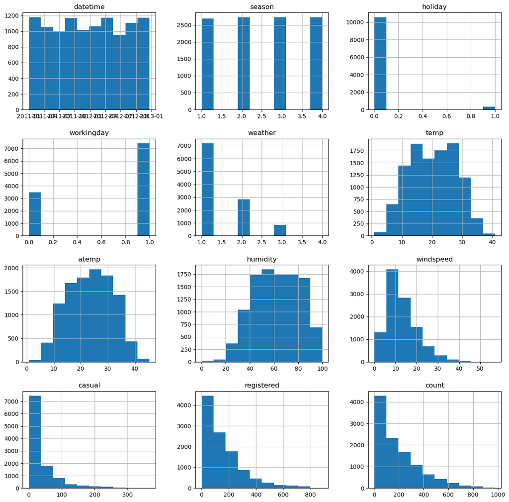

```python
# Create a histogram of all features to show the distribution of each one relative to the data. This is part of the exploritory data analysis
train.hist(figsize=(15,15));
```

```python
# View ranges of internal date components
print("Training Data set ===============================")
print(" year component: ", train.datetime.dt.year.unique())
print("month component: ", train.datetime.dt.month.unique())
print("  day component: ", train.datetime.dt.day.unique())
print(" hour component: ", train.datetime.dt.hour.unique())

print("Test Data set ===============================")
print(" year component: ", test.datetime.dt.year.unique())
print("month component: ", test.datetime.dt.month.unique())
print("  day component: ", test.datetime.dt.day.unique())
print(" hour component: ", test.datetime.dt.hour.unique())
```

```
Training Data set ===============================
 year component:  [2011 2012]
month component:  [ 1  2  3  4  5  6  7  8  9 10 11 12]
  day component:  [ 1  2  3  4  5  6  7  8  9 10 11 12 13 14 15 16 17 18 19]
 hour component:  [ 0  1  2  3  4  5  6  7  8  9 10 11 12 13 14 15 16 17 18 19 20 21 22 23]
Test Data set ===============================
 year component:  [2011 2012]
month component:  [ 1  2  3  4  5  6  7  8  9 10 11 12]
  day component:  [20 21 22 23 24 25 26 27 28 29 30 31]
 hour component:  [ 0  1  2  3  4  5  6  7  8  9 10 11 12 13 14 15 16 17 18 19 20 21 22 23]
```

```python
# create new features
train['year'] = train['datetime'].dt.year
train['month'] = train['datetime'].dt.month
train['day'] = train['datetime'].dt.day
train['hour'] = train['datetime'].dt.hour


test['year'] = test['datetime'].dt.year
test['month'] = test['datetime'].dt.month
test['day'] = test['datetime'].dt.day
test['hour'] = test['datetime'].dt.hour
```

```python
# view training features
train.head()
```

|  | datetime | season | holiday | workingday | weather | temp | atemp | humidity | windspeed | casual | registered | count | year | month | day | hour |
| --- | --- | --- | --- | --- | --- | --- | --- | --- | --- | --- | --- | --- | --- | --- | --- | --- |
| 0 | 2011-01-01 00:00:00 | 1 | 0 | 0 | 1 | 9.84 | 14.395 | 81 | 0.0 | 3 | 13 | 16 | 2011 | 1 | 1 | 0 |
| 1 | 2011-01-01 01:00:00 | 1 | 0 | 0 | 1 | 9.02 | 13.635 | 80 | 0.0 | 8 | 32 | 40 | 2011 | 1 | 1 | 1 |
| 2 | 2011-01-01 02:00:00 | 1 | 0 | 0 | 1 | 9.02 | 13.635 | 80 | 0.0 | 5 | 27 | 32 | 2011 | 1 | 1 | 2 |
| 3 | 2011-01-01 03:00:00 | 1 | 0 | 0 | 1 | 9.84 | 14.395 | 75 | 0.0 | 3 | 10 | 13 | 2011 | 1 | 1 | 3 |
| 4 | 2011-01-01 04:00:00 | 1 | 0 | 0 | 1 | 9.84 | 14.395 | 75 | 0.0 | 0 | 1 | 1 | 2011 | 1 | 1 | 4 |

```python
# view test features
test.head()
```

|  | datetime | season | holiday | workingday | weather | temp | atemp | humidity | windspeed | year | month | day | hour |
| --- | --- | --- | --- | --- | --- | --- | --- | --- | --- | --- | --- | --- | --- |
| 0 | 2011-01-20 00:00:00 | 1 | 0 | 1 | 1 | 10.66 | 11.365 | 56 | 26.0027 | 2011 | 1 | 20 | 0 |
| 1 | 2011-01-20 01:00:00 | 1 | 0 | 1 | 1 | 10.66 | 13.635 | 56 | 0.0000 | 2011 | 1 | 20 | 1 |
| 2 | 2011-01-20 02:00:00 | 1 | 0 | 1 | 1 | 10.66 | 13.635 | 56 | 0.0000 | 2011 | 1 | 20 | 2 |
| 3 | 2011-01-20 03:00:00 | 1 | 0 | 1 | 1 | 10.66 | 12.880 | 56 | 11.0014 | 2011 | 1 | 20 | 3 |
| 4 | 2011-01-20 04:00:00 | 1 | 0 | 1 | 1 | 10.66 | 12.880 | 56 | 11.0014 | 2011 | 1 | 20 | 4 |

# Kaggle Dataset Description

| Field Name | values | meaning |
| --- | --- | --- |
| datetime | hourly date + timestamp | feature |
| season | 1 = spring, 2 = summer, 3 = fall, 4 = winter | feature |
| holiday | whether the day is considered a holiday | feature |
| workingday | whether the day is neither a weekend nor holiday | feature |
| weather | 1: Clear, Few clouds, Partly cloudy, Partly cloudy 2: Mist + Cloudy, Mist + Broken clouds, Mist + Few clouds, Mist 3: Light Snow, Light Rain + Thunderstorm + Scattered clouds, Light Rain + Scattered c… | feature |
| temp | temperature in Celsius | feature |
| atemp | "feels like" temperature in Celsius | feature |
| humidity | relative humidity | feature |
| windspeed | wind speed | feature |
| casual | number of non-registered user rentals initiated | ignored |
| registered | number of registered user rentals initiated | ignored |
| count | number of total rentals | target |

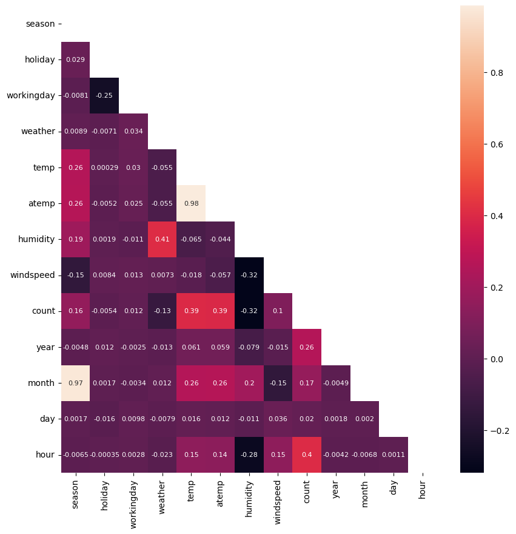

```python
#  View the correlation features*features and features*target

corr_data = train.copy()
corr_data.drop(columns=['casual', 'registered', 'datetime'], inplace=True)
corr_matrix = corr_data.corr()

# Getting the Upper Triangle of the co-relation matrix
matrix = np.triu(corr_matrix)

fig, ax = plt.subplots(figsize=(10,10))
sns.heatmap(corr_matrix, annot=True, mask=matrix, annot_kws={"fontsize":8})
#sns.heatmap(corr_matrix, annot=True, mask=corr_matrix, annot_kws={"fontsize":8})
```

Conclusions:

1. Features: 'temp', 'atemp','hour' and 'year' are highly positively correlated with target 'count'.
2. Features: 'month', 'season' and 'windspeed' are moderately positively correlated with target 'count'.
3. Features: 'weather'and 'humidity' are negatively correlated with target 'count'.
4. Feature 'year' is highly positively correlated with target 'count' =0.26. But this connection looks naive, because there are only two values of this feature in the data, and the popularity of the offer has simply increased
5. Feature 'day' seems to be useless

## Make category types for these so models know they are not just numbers

- AutoGluon originally sees these as ints, but in reality they are int representations of a category.
- Setting the dtype to category will classify these as categories in AutoGluon.

```python
train["season"] = train["season"].astype("category")
train["weather"] = train["weather"].astype("category")
train["workingday"] = train["workingday"].astype("category")
train["holiday"] = train["holiday"].astype("category")

test["season"] = test["season"].astype("category")
test["weather"] = test["weather"].astype("category")
test["workingday"] = test["workingday"].astype("category")
test["holiday"] = test["holiday"].astype("category")
```

```python
# View column types
train.info()
```

```
<class 'pandas.core.frame.DataFrame'>
RangeIndex: 10886 entries, 0 to 10885
Data columns (total 16 columns):
 #   Column      Non-Null Count  Dtype
---  ------      --------------  -----
 0   datetime    10886 non-null  datetime64[ns]
 1   season      10886 non-null  category
 2   holiday     10886 non-null  category
 3   workingday  10886 non-null  category
 4   weather     10886 non-null  category
 5   temp        10886 non-null  float64
 6   atemp       10886 non-null  float64
 7   humidity    10886 non-null  int64
 8   windspeed   10886 non-null  float64
 9   casual      10886 non-null  int64
 10  registered  10886 non-null  int64
 11  count       10886 non-null  int64
 12  year        10886 non-null  int64
 13  month       10886 non-null  int64
 14  day         10886 non-null  int64
 15  hour        10886 non-null  int64
dtypes: category(4), datetime64[ns](1), float64(3), int64(8)
memory usage: 1.0 MB
```

```python
# View are new feature
train.head()
```

|  | datetime | season | holiday | workingday | weather | temp | atemp | humidity | windspeed | casual | registered | count | year | month | day | hour |
| --- | --- | --- | --- | --- | --- | --- | --- | --- | --- | --- | --- | --- | --- | --- | --- | --- |
| 0 | 2011-01-01 00:00:00 | 1 | 0 | 0 | 1 | 9.84 | 14.395 | 81 | 0.0 | 3 | 13 | 16 | 2011 | 1 | 1 | 0 |
| 1 | 2011-01-01 01:00:00 | 1 | 0 | 0 | 1 | 9.02 | 13.635 | 80 | 0.0 | 8 | 32 | 40 | 2011 | 1 | 1 | 1 |
| 2 | 2011-01-01 02:00:00 | 1 | 0 | 0 | 1 | 9.02 | 13.635 | 80 | 0.0 | 5 | 27 | 32 | 2011 | 1 | 1 | 2 |
| 3 | 2011-01-01 03:00:00 | 1 | 0 | 0 | 1 | 9.84 | 14.395 | 75 | 0.0 | 3 | 10 | 13 | 2011 | 1 | 1 | 3 |
| 4 | 2011-01-01 04:00:00 | 1 | 0 | 0 | 1 | 9.84 | 14.395 | 75 | 0.0 | 0 | 1 | 1 | 2011 | 1 | 1 | 4 |

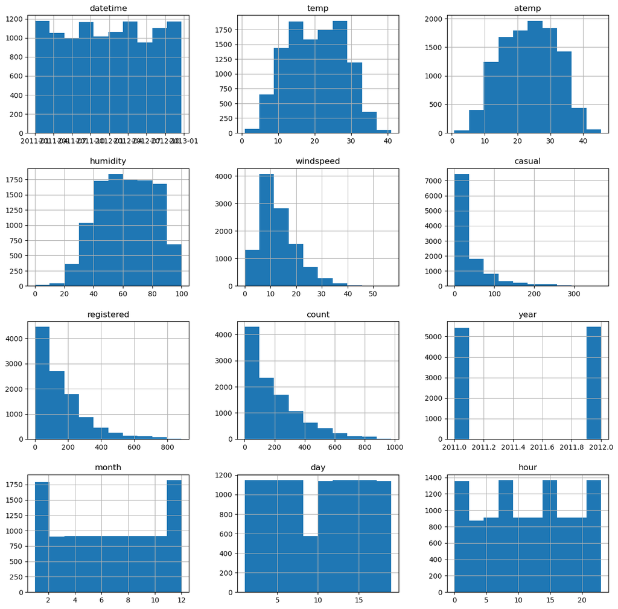

```python
# View histogram of all features again now with the hour feature
train.hist(figsize=(15,15));
```

## Step 5: Rerun the model with the same settings as before, just with more features

```python
predictor_new_features = TabularPredictor(label="count", problem_type='regression', eval_metric="root_mean_squared_error",
learner_kwargs={"ignored_columns": ["casual", "registered", "datetime"]}).fit(train_data=train,
time_limit=600,
presets="best_quality")
```

```
No path specified. Models will be saved in: "AutogluonModels\ag-20230529_082133\"
Presets specified: ['best_quality']
Stack configuration (auto_stack=True): num_stack_levels=1, num_bag_folds=8, num_bag_sets=20
Beginning AutoGluon training ... Time limit = 600s
AutoGluon will save models to "AutogluonModels\ag-20230529_082133\"
AutoGluon Version:  0.6.2
Python Version:     3.7.16
Operating System:   Windows
Platform Machine:   AMD64
Platform Version:   10.0.19041
Train Data Rows:    10886
Train Data Columns: 15
Label Column: count
Preprocessing data ...
Using Feature Generators to preprocess the data ...
Dropping user-specified ignored columns: ['casual', 'registered', 'datetime']
Fitting AutoMLPipelineFeatureGenerator...
	Available Memory:                    6380.05 MB
	Train Data (Original)  Memory Usage: 0.74 MB (0.0% of available memory)
	Inferring data type of each feature based on column values. Set feature_metadata_in to manually specify special dtypes of the features.
	Stage 1 Generators:
		Fitting AsTypeFeatureGenerator...
			Note: Converting 3 features to boolean dtype as they only contain 2 unique values.
	Stage 2 Generators:
		Fitting FillNaFeatureGenerator...
	Stage 3 Generators:
		Fitting IdentityFeatureGenerator...
		Fitting CategoryFeatureGenerator...
			Fitting CategoryMemoryMinimizeFeatureGenerator...
	Stage 4 Generators:
		Fitting DropUniqueFeatureGenerator...
	Types of features in original data (raw dtype, special dtypes):
		('category', []) : 4 | ['season', 'holiday', 'workingday', 'weather']
		('float', [])    : 3 | ['temp', 'atemp', 'windspeed']
		('int', [])      : 5 | ['humidity', 'year', 'month', 'day', 'hour']
	Types of features in processed data (raw dtype, special dtypes):
		('category', [])  : 2 | ['season', 'weather']
		('float', [])     : 3 | ['temp', 'atemp', 'windspeed']
		('int', [])       : 4 | ['humidity', 'month', 'day', 'hour']
		('int', ['bool']) : 3 | ['holiday', 'workingday', 'year']
	0.1s = Fit runtime
	12 features in original data used to generate 12 features in processed data.
	Train Data (Processed) Memory Usage: 0.67 MB (0.0% of available memory)
Data preprocessing and feature engineering runtime = 0.11s ...
AutoGluon will gauge predictive performance using evaluation metric: 'root_mean_squared_error'
	This metric's sign has been flipped to adhere to being higher_is_better. The metric score can be multiplied by -1 to get the metric value.
	To change this, specify the eval_metric parameter of Predictor()
AutoGluon will fit 2 stack levels (L1 to L2) ...
Fitting 11 L1 models ...
Fitting model: KNeighborsUnif_BAG_L1 ... Training model for up to 399.83s of the 599.89s of remaining time.
	-123.9197	 = Validation score   (-root_mean_squared_error)
	0.05s	 = Training   runtime
	0.14s	 = Validation runtime
Fitting model: KNeighborsDist_BAG_L1 ... Training model for up to 381.6s of the 581.66s of remaining time.
	-119.3588	 = Validation score   (-root_mean_squared_error)
	0.07s	 = Training   runtime
	0.11s	 = Validation runtime
Fitting model: LightGBMXT_BAG_L1 ... Training model for up to 381.19s of the 581.25s of remaining time.
Will use sequential fold fitting strategy because import of ray failed. Reason: ray is required to train folds in parallel. A quick tip is to install via `pip install ray==2.0.0`, or use sequential fold fitting by passing `sequential_local` to `ag_args_ensemble` when calling tabular.fitFor example: …
	Fitting 8 child models (S1F1 - S1F8) | Fitting with SequentialLocalFoldFittingStrategy
```

[output not shown]

```
	-37.0978	 = Validation score   (-root_mean_squared_error)
	59.21s	 = Training   runtime
	3.3s	 = Validation runtime
Fitting model: LightGBM_BAG_L1 ... Training model for up to 309.67s of the 509.73s of remaining time.
	Fitting 8 child models (S1F1 - S1F8) | Fitting with SequentialLocalFoldFittingStrategy
```

[output not shown]

```
	-37.6929	 = Validation score   (-root_mean_squared_error)
	20.6s	 = Training   runtime
	0.45s	 = Validation runtime
Fitting model: RandomForestMSE_BAG_L1 ... Training model for up to 285.05s of the 485.11s of remaining time.
	-42.1497	 = Validation score   (-root_mean_squared_error)
	2.41s	 = Training   runtime
	0.49s	 = Validation runtime
Fitting model: CatBoost_BAG_L1 ... Training model for up to 270.8s of the 470.86s of remaining time.
	Fitting 8 child models (S1F1 - S1F8) | Fitting with SequentialLocalFoldFittingStrategy
	Ran out of time, early stopping on iteration 1069.
	Ran out of time, early stopping on iteration 1158.
	Ran out of time, early stopping on iteration 1188.
	Ran out of time, early stopping on iteration 1173.
	Ran out of time, early stopping on iteration 1231.
	Ran out of time, early stopping on iteration 1349.
	Ran out of time, early stopping on iteration 1448.
	Ran out of time, early stopping on iteration 1655.
	-39.867	 = Validation score   (-root_mean_squared_error)
	259.22s	 = Training   runtime
	0.07s	 = Validation runtime
Fitting model: ExtraTreesMSE_BAG_L1 ... Training model for up to 10.81s of the 210.87s of remaining time.
	-41.6203	 = Validation score   (-root_mean_squared_error)
	1.7s	 = Training   runtime
	0.81s	 = Validation runtime
Completed 1/20 k-fold bagging repeats ...
Fitting model: WeightedEnsemble_L2 ... Training model for up to 360.0s of the 195.55s of remaining time.
	-35.9384	 = Validation score   (-root_mean_squared_error)
	0.33s	 = Training   runtime
	0.0s	 = Validation runtime
Fitting 9 L2 models ...
Fitting model: LightGBMXT_BAG_L2 ... Training model for up to 195.19s of the 195.19s of remaining time.
	Fitting 8 child models (S1F1 - S1F8) | Fitting with SequentialLocalFoldFittingStrategy
	-36.9607	 = Validation score   (-root_mean_squared_error)
	5.38s	 = Training   runtime
	0.09s	 = Validation runtime
Fitting model: LightGBM_BAG_L2 ... Training model for up to 189.24s of the 189.23s of remaining time.
	Fitting 8 child models (S1F1 - S1F8) | Fitting with SequentialLocalFoldFittingStrategy
	-36.2298	 = Validation score   (-root_mean_squared_error)
	4.67s	 = Training   runtime
	0.07s	 = Validation runtime
```

[output cut: 67 more lines]

```
	[142]	valid_set's rmse: 32.9011
	Ran out of time, early stopping on iteration 281. Best iteration is:
	[150]	valid_set's rmse: 36.0319
	Ran out of time, early stopping on iteration 400. Best iteration is:
	[158]	valid_set's rmse: 37.5635
	-36.9849	 = Validation score   (-root_mean_squared_error)
	11.01s	 = Training   runtime
	0.1s	 = Validation runtime
Completed 1/20 k-fold bagging repeats ...
Fitting model: WeightedEnsemble_L3 ... Training model for up to 360.0s of the 0.27s of remaining time.
	-35.7801	 = Validation score   (-root_mean_squared_error)
	0.29s	 = Training   runtime
	0.0s	 = Validation runtime
AutoGluon training complete, total runtime = 600.09s ... Best model: "WeightedEnsemble_L3"
TabularPredictor saved. To load, use: predictor = TabularPredictor.load("AutogluonModels\ag-20230529_082133\")
```

```python
predictor_new_features.fit_summary()
```

```
*** Summary of fit() ***
Estimated performance of each model:
                     model   score_val  pred_time_val    fit_time  pred_time_val_marginal  fit_time_marginal  stack_level  can_infer  fit_order
0      WeightedEnsemble_L3  -35.780141       6.871020  481.272507                0.001000           0.293847            3       True         16
1      WeightedEnsemble_L2  -35.938429       4.320498  341.772910                0.000000           0.329825            2       True          8
2     ExtraTreesMSE_BAG_L2  -36.005493       6.179429  345.562653                0.801524           2.306198            2       True         13
3          LightGBM_BAG_L2  -36.229765       5.450864  347.929781                0.072959           4.673326            2       True         10
4          CatBoost_BAG_L2  -36.259673       5.430828  468.570015                0.052923         125.313560            2       True         12
5   RandomForestMSE_BAG_L2  -36.589667       5.942613  348.685576                0.564709           5.429121            2       True         11
6           XGBoost_BAG_L2  -36.673342       5.492839  349.828043                0.114934           6.571588            2       True         14
7        LightGBMXT_BAG_L2  -36.960704       5.470846  348.638366                0.092942           5.381911            2       True          9
8     LightGBMLarge_BAG_L2  -36.984899       5.479842  354.267163                0.101937          11.010708            2       True         15
9        LightGBMXT_BAG_L1  -37.097828       3.304104   59.213003                3.304104          59.213003            1       True          3
10         LightGBM_BAG_L1  -37.692850       0.452720   20.598122                0.452720          20.598122            1       True          4
11         CatBoost_BAG_L1  -39.866994       0.072952  259.224061                0.072952         259.224061            1       True          6
12    ExtraTreesMSE_BAG_L1  -41.620336       0.806549    1.695437                0.806549           1.695437            1       True          7
13  RandomForestMSE_BAG_L1  -42.149734       0.490722    2.407899                0.490722           2.407899            1       True          5
14   KNeighborsDist_BAG_L1 -119.358812       0.110939    0.069960                0.110939           0.069960            1       True          2
15   KNeighborsUnif_BAG_L1 -123.919678       0.139919    0.047972                0.139919           0.047972            1       True          1
Number of models trained: 16
Types of models trained:
{'StackerEnsembleModel_CatBoost', 'StackerEnsembleModel_XT', 'WeightedEnsembleModel', 'StackerEnsembleModel_RF', 'StackerEnsembleModel_XGBoost', 'StackerEnsembleModel_LGB', 'StackerEnsembleModel_KNN'}
Bagging used: True  (with 8 folds)
Multi-layer stack-ensembling used: True  (with 3 levels)
Feature Metadata (Processed):
(raw dtype, special dtypes):
('category', [])  : 2 | ['season', 'weather']
('float', [])     : 3 | ['temp', 'atemp', 'windspeed']
('int', [])       : 4 | ['humidity', 'month', 'day', 'hour']
('int', ['bool']) : 3 | ['holiday', 'workingday', 'year']
Plot summary of models saved to file: AutogluonModels\ag-20230529_082133\SummaryOfModels.html
*** End of fit() summary ***
```

[output not shown]

[output cut: 151 more lines]

[output not shown]

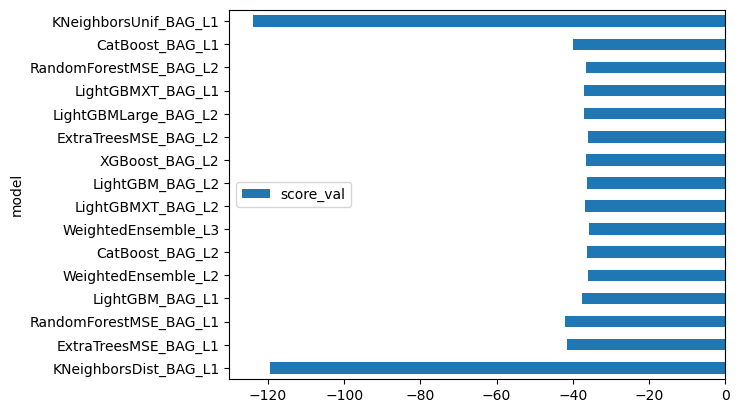

```python
predictor_new_features.leaderboard(train, silent=True).plot(kind='barh', y='score_val', x='model')
```

```python
# Create predictions from test dataset
predictions_new_features = predictor_new_features.predict(test)
predictions_new_features.head()
```

```
0    13.541490
1     6.162855
2     5.644586
3     4.809571
4     4.536358
Name: count, dtype: float32
```

```python
# Describe the `predictions` series to see if there are any negative values
predictions_new_features.describe()
```

```
count    6493.000000
mean      189.375244
std       173.187851
min         4.056870
25%        46.800522
50%       146.844208
75%       281.030884
max       887.226013
Name: count, dtype: float64
```

```python
# How many negative values do we have?
print("Total predictions             :", len(predictions_new_features))
print("Total non-negative predictios :", (predictions_new_features >= 0).sum())
print("Total negative predictios     :", (predictions_new_features < 0).sum())
```

```
Total predictions             : 6493
Total non-negative predictios : 6493
Total negative predictios     : 0
```

```python
# Remember to set all negative values to zero
# Set them to zero
predictions_new_features[predictions<0] = 0    # Only needed if prediction values < 0

# Is the problem solved?
print("Total predictions             :", len(predictions_new_features))
print("Total non-negative predictios :", (predictions_new_features >= 0).sum())
print("Total negative predictios     :", (predictions_new_features < 0).sum())
```

[output not shown]

```python
# Same submitting predictions
submission_new_features["count"] = predictions_new_features
submission_new_features.to_csv("submission_new_features.csv", index=False)
```

```python
!kaggle competitions submit -c bike-sharing-demand -f submission_new_features.csv -m "new features"
```

```
Successfully submitted to Bike Sharing Demand
```

```
  4%|4         | 8.00k/195k [00:00<00:05, 38.2kB/s]
```

```python
!kaggle competitions submissions -c bike-sharing-demand | tail -n +1 | head -n 6
```

```
fileName                     date                 description           status    publicScore  privateScore
---------------------------  -------------------  --------------------  --------  -----------  ------------
submission_new_features.csv  2023-05-29 09:01:21  new features          complete  0.46416      0.46416
submission.csv               2023-05-28 08:17:53  first raw submission  complete  1.80912      1.80912
```

#### New Score of `0.46416`

**Much better**  
, but to join the leaderboard the score needs to be improved by 0.1

```python
## Save data files for future processing
#
train.to_csv("train_augmented.csv", index=False)
test.to_csv("test_augmented.csv", index=False)
```

## Step 6: Hyper parameter optimization

- There are many options for hyper parameter optimization.
- Options are to change the AutoGluon higher level parameters or the individual model hyperparameters.
- The hyperparameters of the models themselves that are in AutoGluon. Those need the `hyperparameter` and `hyperparameter_tune_kwargs` arguments.

```python
# This part of the notebook will be rolled out many times, so:

# Re-import all needed libraries
import pandas as pd
from autogluon.tabular import TabularPredictor
import matplotlib.pyplot as plt
import numpy as np
import seaborn as sns

# Re-import data files
train = pd.read_csv("train_augmented.csv",parse_dates=["datetime"])
test = pd.read_csv("test_augmented.csv",parse_dates=["datetime"])
submission_new_hpo = pd.read_csv("sampleSubmission.csv",parse_dates=["datetime"])
```

```python
# I will define labels for the parameters, because there will be many more now
#
eval_metric = 'root_mean_squared_error'
ignored_columns = ["casual", "registered","datetime"]   # Ignored columns while training
label = 'count'
num_trials = 5                       # try at most 5 different hyperparameter configurations for each type of model

presets = "best_quality"             # high predictive accuracy, slower inference times and higher disk usage
#presets = "high_quality"             # high predictive accuracy and fast inference
#presets = "good_quality"             # good predictive accuracy and very fast inference
#presets = "medium_quality"           # medium predictive accuracy, very fast inference and training time
#presets = "optimize_for_deployment"  # delete unused models and remove training artifacts
#presets = "interpretable"            # fits only interpretable rule-based models from the imodels package

search_strategy = 'auto'             # to tune hyperparameters using random search routine with a local scheduler
scheduler = 'local'                  # Local FIFO scheduler
time_limit = 120*60                  # 60 minutes -> 60*60 seconds
train_data = train                   # 'casual' and 'registered' columns are already dropped/ignored

# ======================================================================================================================
## sources:
# https://auto.gluon.ai/stable/tutorials/tabular/tabular-indepth.html#specifying-hyperparameters-and-tuning-them

# https://forecastegy.com/posts/catboost-hyperparameter-tuning-guide-with-optuna/

# AutoML with Tabular data - Using AutoGluon (KDD 2020)
# https://github.com/jwmueller/KDD20-tutorial
# Tutorial 1: https://www.youtube.com/watch?v=eDUulk6BWzY
# Tutorial 2: https://www.youtube.com/watch?v=MstnE2VFKR8

# https://auto.gluon.ai/dev/api/autogluon.tabular.models.html

# https://github.com/aws/amazon-sagemaker-examples
# https://github.com/aws/amazon-sagemaker-examples/blob/main/introduction_to_amazon_algorithms/lightgbm_catboost_tabular/Amazon_Tabular_Classification_LightGBM_CatBoost.ipynb
# sources: # https://github.com/aws/amazon-sagemaker-examples/blob/main/introduction_to_amazon_algorithms/lightgbm_catboost_tabular/Amazon_Tabular_Classification_LightGBM_CatBoost.ipynb

# ======================================================================================================================
import autogluon.core as ag

nn_options = {  # specifies non-default hyperparameter values for neural network models
    'num_epochs': 10,  # number of training epochs (controls training time of NN models)
    'learning_rate': ag.space.Real(1e-4, 1e-2, default=5e-4, log=True),  # learning rate used in training (real-valued hyperparameter searched on log-scale)
    'activation': ag.space.Categorical('relu', 'softrelu', 'tanh'),  # activation function used in NN (categorical hyperparameter, default = first entry)
    'dropout_prob': ag.space.Real(0.0, 0.5, default=0.1),  # dropout probability (real-valued hyperparameter)
}

gbm_options = {  # specifies non-default hyperparameter values for lightGBM gradient boosted trees
    'num_boost_round': 100,  # number of boosting rounds (controls training time of GBM models)
    'num_leaves': ag.space.Int(lower=26, upper=66, default=36),  # number of leaves in trees (integer hyperparameter)
}

cat_options = {
    'iterations' : 100,
    'learning_rate' : ag.space.Real(lower=0.001, upper=0.1, log=True),
    'depth' : ag.space.Int(lower=6, upper=10)
}

xgb_options = {
    'max_depth' : ag.space.Int(lower=6, upper=10, default=6),
    'eta' : ag.space.Real(lower=0.01, upper=0.3, log=True)
}

hyperparameters = {  # hyperparameters of each model type
                   'CAT' : cat_options,     # CatBoost
                   'GBM' : gbm_options,     # lightGBM gradient boosted trees
                   #'NN_MXNET': nn_options,  # TabularNeuralNetMxnetModel (alias "NN" & "NN_MXNET") has been deprecated in v0.4.0
                   'XGB' : xgb_options,
                   #'NN_TORCH': nn_options   # neural network implemented in Pytorch
                   #'RF' :  # random forest
                  }  # When these keys are missing from hyperparameters dict, no models of that type are trained

# time_limit = 30*60  # 30 minutes -> 30*60 seconds
# num_trials = 5  # try at most 5 different hyperparameter configurations for each type of model
# search_strategy = 'auto'  # to tune hyperparameters using random search routine with a local scheduler

hyperparameter_tune_kwargs = {  # HPO is not performed unless hyperparameter_tune_kwargs is specified
    'num_trials': num_trials,
    'scheduler' : scheduler,
    'searcher': search_strategy,
}

# predictor = TabularPredictor(label=label, eval_metric=metric)
#             .fit(train_data, tuning_data=val_data, time_limit=time_limit,
#                  hyperparameters=hyperparameters, hyperparameter_tune_kwargs=hyperparameter_tune_kwargs,)
```

```python
# previous attempt
# predictor_new_features = TabularPredictor(label="count", problem_type='regression', eval_metric="root_mean_squared_error",
# learner_kwargs={"ignored_columns": ["casual", "registered", "datetime"]}).fit(train_data=train,
# time_limit=600,
# presets="best_quality")

predictor_new_hpo = TabularPredictor(label=label,
                                     problem_type='regression',
                                     eval_metric=eval_metric,
                                     learner_kwargs={"ignored_columns":ignored_columns}) \
                    .fit(train_data=train_data,
                         time_limit=time_limit,
                         presets=presets,
                         hyperparameters=hyperparameters,
                         hyperparameter_tune_kwargs=hyperparameter_tune_kwargs,
                         refit_full='best')
```

```
No path specified. Models will be saved in: "AutogluonModels\ag-20230531_194015\"
Presets specified: ['best_quality']
Warning: hyperparameter tuning is currently experimental and may cause the process to hang.
Stack configuration (auto_stack=True): num_stack_levels=1, num_bag_folds=8, num_bag_sets=20
Beginning AutoGluon training ... Time limit = 7200s
AutoGluon will save models to "AutogluonModels\ag-20230531_194015\"
AutoGluon Version:  0.6.2
Python Version:     3.7.16
Operating System:   Windows
Platform Machine:   AMD64
Platform Version:   10.0.19041
Train Data Rows:    10886
Train Data Columns: 15
Label Column: count
Preprocessing data ...
Using Feature Generators to preprocess the data ...
Dropping user-specified ignored columns: ['casual', 'registered', 'datetime']
Fitting AutoMLPipelineFeatureGenerator...
	Available Memory:                    7470.72 MB
	Train Data (Original)  Memory Usage: 1.05 MB (0.0% of available memory)
	Inferring data type of each feature based on column values. Set feature_metadata_in to manually specify special dtypes of the features.
	Stage 1 Generators:
		Fitting AsTypeFeatureGenerator...
			Note: Converting 3 features to boolean dtype as they only contain 2 unique values.
	Stage 2 Generators:
		Fitting FillNaFeatureGenerator...
	Stage 3 Generators:
		Fitting IdentityFeatureGenerator...
	Stage 4 Generators:
		Fitting DropUniqueFeatureGenerator...
	Types of features in original data (raw dtype, special dtypes):
		('float', []) : 3 | ['temp', 'atemp', 'windspeed']
		('int', [])   : 9 | ['season', 'holiday', 'workingday', 'weather', 'humidity', ...]
	Types of features in processed data (raw dtype, special dtypes):
		('float', [])     : 3 | ['temp', 'atemp', 'windspeed']
		('int', [])       : 6 | ['season', 'weather', 'humidity', 'month', 'day', ...]
		('int', ['bool']) : 3 | ['holiday', 'workingday', 'year']
	0.1s = Fit runtime
	12 features in original data used to generate 12 features in processed data.
	Train Data (Processed) Memory Usage: 0.82 MB (0.0% of available memory)
Data preprocessing and feature engineering runtime = 0.08s ...
AutoGluon will gauge predictive performance using evaluation metric: 'root_mean_squared_error'
	This metric's sign has been flipped to adhere to being higher_is_better. The metric score can be multiplied by -1 to get the metric value.
	To change this, specify the eval_metric parameter of Predictor()
AutoGluon will fit 2 stack levels (L1 to L2) ...
Fitting 3 L1 models ...
Hyperparameter tuning model: LightGBM_BAG_L1 ... Tuning model for up to 1439.62s of the 7199.92s of remaining time.
```

```
Will use sequential fold fitting strategy because import of ray failed. Reason: ray is required to train folds in parallel. A quick tip is to install via `pip install ray==2.0.0`, or use sequential fold fitting by passing `sequential_local` to `ag_args_ensemble` when calling tabular.fitFor example: …
	Fitting 8 child models (S1F1 - S1F8) | Fitting with SequentialLocalFoldFittingStrategy
	Fitting 8 child models (S1F1 - S1F8) | Fitting with SequentialLocalFoldFittingStrategy
	Fitting 8 child models (S1F1 - S1F8) | Fitting with SequentialLocalFoldFittingStrategy
	Fitting 8 child models (S1F1 - S1F8) | Fitting with SequentialLocalFoldFittingStrategy
	Fitting 8 child models (S1F1 - S1F8) | Fitting with SequentialLocalFoldFittingStrategy
Fitted model: LightGBM_BAG_L1\T1 ...
	-44.6941	 = Validation score   (-root_mean_squared_error)
	10.69s	 = Training   runtime
	0.0s	 = Validation runtime
Fitted model: LightGBM_BAG_L1\T2 ...
	-43.1782	 = Validation score   (-root_mean_squared_error)
	2.02s	 = Training   runtime
	0.0s	 = Validation runtime
Fitted model: LightGBM_BAG_L1\T3 ...
	-43.2296	 = Validation score   (-root_mean_squared_error)
	2.44s	 = Training   runtime
	0.0s	 = Validation runtime
Fitted model: LightGBM_BAG_L1\T4 ...
	-124.4833	 = Validation score   (-root_mean_squared_error)
	2.29s	 = Training   runtime
	0.0s	 = Validation runtime
Fitted model: LightGBM_BAG_L1\T5 ...
	-47.9116	 = Validation score   (-root_mean_squared_error)
	2.4s	 = Training   runtime
	0.0s	 = Validation runtime
Hyperparameter tuning model: CatBoost_BAG_L1 ... Tuning model for up to 1439.62s of the 7178.17s of remaining time.
```

```
	Fitting 8 child models (S1F1 - S1F8) | Fitting with SequentialLocalFoldFittingStrategy
	Fitting 8 child models (S1F1 - S1F8) | Fitting with SequentialLocalFoldFittingStrategy
	Fitting 8 child models (S1F1 - S1F8) | Fitting with SequentialLocalFoldFittingStrategy
	Fitting 8 child models (S1F1 - S1F8) | Fitting with SequentialLocalFoldFittingStrategy
	Fitting 8 child models (S1F1 - S1F8) | Fitting with SequentialLocalFoldFittingStrategy
Fitted model: CatBoost_BAG_L1\T1 ...
	-170.5264	 = Validation score   (-root_mean_squared_error)
	3.86s	 = Training   runtime
	0.0s	 = Validation runtime
Fitted model: CatBoost_BAG_L1\T2 ...
	-45.904	 = Validation score   (-root_mean_squared_error)
	6.15s	 = Training   runtime
	0.0s	 = Validation runtime
Fitted model: CatBoost_BAG_L1\T3 ...
	-114.6048	 = Validation score   (-root_mean_squared_error)
	4.06s	 = Training   runtime
	0.0s	 = Validation runtime
Fitted model: CatBoost_BAG_L1\T4 ...
	-47.6884	 = Validation score   (-root_mean_squared_error)
	2.57s	 = Training   runtime
	0.0s	 = Validation runtime
Fitted model: CatBoost_BAG_L1\T5 ...
	-118.0846	 = Validation score   (-root_mean_squared_error)
	2.24s	 = Training   runtime
	0.0s	 = Validation runtime
Hyperparameter tuning model: XGBoost_BAG_L1 ... Tuning model for up to 1439.62s of the 7159.09s of remaining time.
```

```
	Fitting 8 child models (S1F1 - S1F8) | Fitting with SequentialLocalFoldFittingStrategy
	Fitting 8 child models (S1F1 - S1F8) | Fitting with SequentialLocalFoldFittingStrategy
	Fitting 8 child models (S1F1 - S1F8) | Fitting with SequentialLocalFoldFittingStrategy
	Fitting 8 child models (S1F1 - S1F8) | Fitting with SequentialLocalFoldFittingStrategy
	Fitting 8 child models (S1F1 - S1F8) | Fitting with SequentialLocalFoldFittingStrategy
Fitted model: XGBoost_BAG_L1\T1 ...
	-39.3299	 = Validation score   (-root_mean_squared_error)
	13.76s	 = Training   runtime
	0.0s	 = Validation runtime
Fitted model: XGBoost_BAG_L1\T2 ...
	-38.8171	 = Validation score   (-root_mean_squared_error)
	31.2s	 = Training   runtime
	0.0s	 = Validation runtime
Fitted model: XGBoost_BAG_L1\T3 ...
	-38.9366	 = Validation score   (-root_mean_squared_error)
	81.58s	 = Training   runtime
	0.0s	 = Validation runtime
Fitted model: XGBoost_BAG_L1\T4 ...
	-39.5654	 = Validation score   (-root_mean_squared_error)
	13.53s	 = Training   runtime
	0.0s	 = Validation runtime
Fitted model: XGBoost_BAG_L1\T5 ...
	-39.0797	 = Validation score   (-root_mean_squared_error)
	139.87s	 = Training   runtime
	0.0s	 = Validation runtime
Repeating k-fold bagging: 2/20
Fitting model: LightGBM_BAG_L1\T1 ... Training model for up to 4477.75s of the 6878.92s of remaining time.
	Fitting 8 child models (S2F1 - S2F8) | Fitting with SequentialLocalFoldFittingStrategy
	-44.2228	 = Validation score   (-root_mean_squared_error)
	12.68s	 = Training   runtime
	0.05s	 = Validation runtime
Fitting model: LightGBM_BAG_L1\T2 ... Training model for up to 4475.49s of the 6876.66s of remaining time.
	Fitting 8 child models (S2F1 - S2F8) | Fitting with SequentialLocalFoldFittingStrategy
	-42.7316	 = Validation score   (-root_mean_squared_error)
	3.96s	 = Training   runtime
	0.08s	 = Validation runtime
Fitting model: LightGBM_BAG_L1\T3 ... Training model for up to 4473.2s of the 6874.37s of remaining time.
	Fitting 8 child models (S2F1 - S2F8) | Fitting with SequentialLocalFoldFittingStrategy
	-42.8102	 = Validation score   (-root_mean_squared_error)
	4.75s	 = Training   runtime
```

[output cut: 965 more lines]

```
	-38.1602	 = Validation score   (-root_mean_squared_error)
	200.59s	 = Training   runtime
	3.5s	 = Validation runtime
Fitting model: XGBoost_BAG_L1\T5 ... Training model for up to 365.61s of the 2766.78s of remaining time.
	Fitting 8 child models (S14F1 - S14F8) | Fitting with SequentialLocalFoldFittingStrategy
	-37.6925	 = Validation score   (-root_mean_squared_error)
	1770.82s	 = Training   runtime
	50.26s	 = Validation runtime
Completed 14/20 k-fold bagging repeats ...
Fitting model: WeightedEnsemble_L2 ... Training model for up to 479.87s of the 2602.28s of remaining time.
	-36.8815	 = Validation score   (-root_mean_squared_error)
	0.82s	 = Training   runtime
	0.0s	 = Validation runtime
Fitting 3 L2 models ...
Hyperparameter tuning model: LightGBM_BAG_L2 ... Tuning model for up to 780.43s of the 2601.4s of remaining time.
```

[output not shown]

[output not shown]

[output not shown]

[output cut: 644 more lines]

```
Fitting 1 L2 models ...
Fitting model: LightGBM_BAG_L2\T3_FULL ...
	0.31s	 = Training   runtime
Fitting 1 L2 models ...
Fitting model: CatBoost_BAG_L2\T4_FULL ...
	1.35s	 = Training   runtime
Fitting 1 L2 models ...
Fitting model: XGBoost_BAG_L2\T1_FULL ...
	0.3s	 = Training   runtime
Fitting 1 L2 models ...
Fitting model: XGBoost_BAG_L2\T4_FULL ...
	0.16s	 = Training   runtime
Fitting model: WeightedEnsemble_L3_FULL | Skipping fit via cloning parent ...
	0.68s	 = Training   runtime
TabularPredictor saved. To load, use: predictor = TabularPredictor.load("AutogluonModels\ag-20230531_194015\")
```

```python
predictor_new_hpo.fit_summary()
```

```
*** Summary of fit() ***
Estimated performance of each model:
                       model   score_val  pred_time_val     fit_time  pred_time_val_marginal  fit_time_marginal  stack_level  can_infer  fit_order
0        WeightedEnsemble_L3  -36.850900     106.231734  4109.197567                0.000000           0.680611            3       True         32
1        WeightedEnsemble_L2  -36.881467      60.553334  2435.739368                0.000999           0.817532            2       True         16
2          XGBoost_BAG_L2\T4  -36.990616     104.826403  3901.976000                0.673620          58.720726            2       True         30
3          XGBoost_BAG_L2\T1  -37.079068     104.828400  3921.401736                0.675617          78.146462            2       True         27
4         LightGBM_BAG_L2\T3  -37.142117     104.618623  3871.630999                0.465840          28.375725            2       True         19
5          XGBoost_BAG_L2\T3  -37.146836     105.242169  3965.721599                1.089386         122.466325            2       True         29
6         LightGBM_BAG_L2\T2  -37.182302     104.509067  3865.129533                0.356284          21.874259            2       True         18
7         LightGBM_BAG_L2\T1  -37.218564     104.525519  3866.876729                0.372736          23.621454            2       True         17
8         CatBoost_BAG_L2\T4  -37.254374     104.416656  3943.274043                0.263873         100.018769            2       True         25
9         LightGBM_BAG_L2\T5  -37.404723     104.553476  3868.025225                0.400693          24.769951            2       True         21
10        CatBoost_BAG_L2\T2  -37.467066     104.489576  4331.253131                0.336792         487.997857            2       True         23
11         XGBoost_BAG_L1\T2  -37.494846       4.301761   316.930414                4.301761         316.930414            1       True         12
```

[output cut: 52 more lines]

[output not shown]

[output cut: 577 more lines]

```
 37         44
 38         43
 39         52
 40         48
 41         37
 42         36
 43         35
 44         34
 45         33
 46         49
 47         42
 48         41
 49         40
 50         39
 51         38  }
```

```python
# Leaderboard dataframe
leaderboard_new_hpo_df = pd.DataFrame(predictor_new_hpo.leaderboard(silent=True))
leaderboard_new_hpo_df
```

[output not shown]

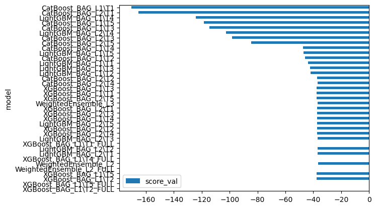

```python
predictor_new_hpo.leaderboard(train, silent=True).plot(kind='barh', y='score_val', x='model')
```

```python
# Create predictions from test dataset
predictions_new_hpo = predictor_new_hpo.predict(test)
predictions_new_hpo.head()
```

```
0    16.186251
1     3.245836
2     2.310236
3     0.807159
4     0.529725
Name: count, dtype: float32
```

```python
# Describe the `predictions` series to see if there are any negative values
predictions_new_hpo.describe()
```

```
count    6493.000000
mean      189.351547
std       172.092178
min       -21.770697
25%        47.565418
50%       146.119492
75%       284.063934
max       864.059509
Name: count, dtype: float64
```

```python
# How many negative values do we have?
print("Total predictions             :", len(predictions_new_hpo))
print("Total non-negative predictios :", (predictions_new_hpo >= 0).sum())
print("Total negative predictios     :", (predictions_new_hpo < 0).sum())
```

```
Total predictions             : 6493
Total non-negative predictios : 6392
Total negative predictios     : 101
```

```python
# Remember to set all negative values to zero
# Set them to zero
predictions_new_hpo[predictions_new_hpo<0] = 0    # Only needed if prediction values < 0
```

```python
# Is the problem solved?
print("Total predictions             :", len(predictions_new_hpo))
print("Total non-negative predictios :", (predictions_new_hpo >= 0).sum())
print("Total negative predictios     :", (predictions_new_hpo < 0).sum())
```

```
Total predictions             : 6493
Total non-negative predictios : 6493
Total negative predictios     : 0
```

```python
# Same submitting predictions
submission_new_hpo["count"] = predictions_new_hpo
submission_new_hpo.to_csv("submission_new_hpo.csv", index=False)

submission_new_hpo
```

|  | datetime | count |
| --- | --- | --- |
| 0 | 2011-01-20 00:00:00 | 16.186251 |
| 1 | 2011-01-20 01:00:00 | 3.245836 |
| 2 | 2011-01-20 02:00:00 | 2.310236 |
| 3 | 2011-01-20 03:00:00 | 0.807159 |
| 4 | 2011-01-20 04:00:00 | 0.529725 |
| ... | ... | ... |
| 6488 | 2012-12-31 19:00:00 | 267.732483 |
| 6489 | 2012-12-31 20:00:00 | 183.366974 |
| 6490 | 2012-12-31 21:00:00 | 140.310028 |
| 6491 | 2012-12-31 22:00:00 | 103.991478 |
| 6492 | 2012-12-31 23:00:00 | 55.853619 |

6493 rows × 2 columns

```python
!kaggle competitions submit -c bike-sharing-demand -f submission_new_hpo.csv -m "new features with hyperparameters"
```

```
Successfully submitted to Bike Sharing Demand
```

```
  4%|4         | 8.00k/194k [00:00<00:04, 45.4kB/s]
```

```python
!kaggle competitions submissions -c bike-sharing-demand | tail -n +1 | head -n 6
```

```
fileName                     date                 description                        status    publicScore  privateScore
---------------------------  -------------------  ---------------------------------  --------  -----------  ------------
submission_new_hpo.csv       2023-05-30 21:26:39  new features with hyperparameters  complete  0.54626      0.54626
submission_new_features.csv  2023-05-29 09:01:21  new features                       complete  0.46416      0.46416
submission.csv               2023-05-28 08:17:53  first raw submission               complete  1.80912      1.80912
```

#### New Score of `0.54626`

**Worse result than the previous attempt.**

Unfortunately, the best model after hyperparameter tuning seems to be overtrained

### Parsing feature `datetime` to obtain one more feature: day of week `weekday`

```python
## Create new feature !
# Parsing feature `datetime` to obtain one more feature: day of week `weekday`

train['weekday'] = train['datetime'].dt.dayofweek
test['weekday'] = test['datetime'].dt.dayofweek
```

```python
train.head()
```

|  | datetime | season | holiday | workingday | weather | temp | atemp | humidity | windspeed | casual | registered | count | year | month | day | hour | weekday |
| --- | --- | --- | --- | --- | --- | --- | --- | --- | --- | --- | --- | --- | --- | --- | --- | --- | --- |
| 0 | 2011-01-01 00:00:00 | 1 | 0 | 0 | 1 | 9.84 | 14.395 | 81 | 0.0 | 3 | 13 | 16 | 2011 | 1 | 1 | 0 | 5 |
| 1 | 2011-01-01 01:00:00 | 1 | 0 | 0 | 1 | 9.02 | 13.635 | 80 | 0.0 | 8 | 32 | 40 | 2011 | 1 | 1 | 1 | 5 |
| 2 | 2011-01-01 02:00:00 | 1 | 0 | 0 | 1 | 9.02 | 13.635 | 80 | 0.0 | 5 | 27 | 32 | 2011 | 1 | 1 | 2 | 5 |
| 3 | 2011-01-01 03:00:00 | 1 | 0 | 0 | 1 | 9.84 | 14.395 | 75 | 0.0 | 3 | 10 | 13 | 2011 | 1 | 1 | 3 | 5 |
| 4 | 2011-01-01 04:00:00 | 1 | 0 | 0 | 1 | 9.84 | 14.395 | 75 | 0.0 | 0 | 1 | 1 | 2011 | 1 | 1 | 4 | 5 |

```python
test.head()
```

|  | datetime | season | holiday | workingday | weather | temp | atemp | humidity | windspeed | year | month | day | hour | weekday |
| --- | --- | --- | --- | --- | --- | --- | --- | --- | --- | --- | --- | --- | --- | --- |
| 0 | 2011-01-20 00:00:00 | 1 | 0 | 1 | 1 | 10.66 | 11.365 | 56 | 26.0027 | 2011 | 1 | 20 | 0 | 3 |
| 1 | 2011-01-20 01:00:00 | 1 | 0 | 1 | 1 | 10.66 | 13.635 | 56 | 0.0000 | 2011 | 1 | 20 | 1 | 3 |
| 2 | 2011-01-20 02:00:00 | 1 | 0 | 1 | 1 | 10.66 | 13.635 | 56 | 0.0000 | 2011 | 1 | 20 | 2 | 3 |
| 3 | 2011-01-20 03:00:00 | 1 | 0 | 1 | 1 | 10.66 | 12.880 | 56 | 11.0014 | 2011 | 1 | 20 | 3 | 3 |
| 4 | 2011-01-20 04:00:00 | 1 | 0 | 1 | 1 | 10.66 | 12.880 | 56 | 11.0014 | 2011 | 1 | 20 | 4 | 3 |

```python
predictor_new_hpo_wd = TabularPredictor(label=label,
                                     problem_type='regression',
                                     eval_metric=eval_metric,
                                     learner_kwargs={"ignored_columns":ignored_columns}) \
                    .fit(train_data=train_data,
                         time_limit=time_limit,
                         presets=presets,
                         hyperparameters=hyperparameters,
                         hyperparameter_tune_kwargs=hyperparameter_tune_kwargs,
                         refit_full='best')
```

```
No path specified. Models will be saved in: "AutogluonModels\ag-20230531_220935\"
Presets specified: ['best_quality']
Warning: hyperparameter tuning is currently experimental and may cause the process to hang.
Stack configuration (auto_stack=True): num_stack_levels=1, num_bag_folds=8, num_bag_sets=20
Beginning AutoGluon training ... Time limit = 7200s
AutoGluon will save models to "AutogluonModels\ag-20230531_220935\"
AutoGluon Version:  0.6.2
Python Version:     3.7.16
Operating System:   Windows
Platform Machine:   AMD64
Platform Version:   10.0.19041
Train Data Rows:    10886
Train Data Columns: 16
Label Column: count
Preprocessing data ...
Using Feature Generators to preprocess the data ...
Dropping user-specified ignored columns: ['casual', 'registered', 'datetime']
Fitting AutoMLPipelineFeatureGenerator...
	Available Memory:                    8540.28 MB
	Train Data (Original)  Memory Usage: 1.13 MB (0.0% of available memory)
	Inferring data type of each feature based on column values. Set feature_metadata_in to manually specify special dtypes of the features.
	Stage 1 Generators:
		Fitting AsTypeFeatureGenerator...
			Note: Converting 3 features to boolean dtype as they only contain 2 unique values.
	Stage 2 Generators:
		Fitting FillNaFeatureGenerator...
	Stage 3 Generators:
		Fitting IdentityFeatureGenerator...
	Stage 4 Generators:
		Fitting DropUniqueFeatureGenerator...
	Types of features in original data (raw dtype, special dtypes):
		('float', []) :  3 | ['temp', 'atemp', 'windspeed']
		('int', [])   : 10 | ['season', 'holiday', 'workingday', 'weather', 'humidity', ...]
	Types of features in processed data (raw dtype, special dtypes):
		('float', [])     : 3 | ['temp', 'atemp', 'windspeed']
		('int', [])       : 7 | ['season', 'weather', 'humidity', 'month', 'day', ...]
		('int', ['bool']) : 3 | ['holiday', 'workingday', 'year']
	0.1s = Fit runtime
	13 features in original data used to generate 13 features in processed data.
	Train Data (Processed) Memory Usage: 0.9 MB (0.0% of available memory)
Data preprocessing and feature engineering runtime = 0.09s ...
AutoGluon will gauge predictive performance using evaluation metric: 'root_mean_squared_error'
	This metric's sign has been flipped to adhere to being higher_is_better. The metric score can be multiplied by -1 to get the metric value.
	To change this, specify the eval_metric parameter of Predictor()
AutoGluon will fit 2 stack levels (L1 to L2) ...
Fitting 3 L1 models ...
Hyperparameter tuning model: LightGBM_BAG_L1 ... Tuning model for up to 1439.62s of the 7199.91s of remaining time.
```

[output not shown]

[output not shown]

[output not shown]

[output cut: 889 more lines]

```
	-34.3077	 = Validation score   (-root_mean_squared_error)
	195.07s	 = Training   runtime
	3.58s	 = Validation runtime
Fitting model: XGBoost_BAG_L1\T5 ... Training model for up to 521.2s of the 2922.37s of remaining time.
	Fitting 8 child models (S13F1 - S13F8) | Fitting with SequentialLocalFoldFittingStrategy
	-33.7709	 = Validation score   (-root_mean_squared_error)
	1750.68s	 = Training   runtime
	53.3s	 = Validation runtime
Completed 13/20 k-fold bagging repeats ...
Fitting model: WeightedEnsemble_L2 ... Training model for up to 479.87s of the 2739.34s of remaining time.
	-33.0708	 = Validation score   (-root_mean_squared_error)
	0.82s	 = Training   runtime
	0.0s	 = Validation runtime
Fitting 3 L2 models ...
Hyperparameter tuning model: LightGBM_BAG_L2 ... Tuning model for up to 821.55s of the 2738.47s of remaining time.
```

[output not shown]

[output not shown]

[output not shown]

[output cut: 602 more lines]

```
Fitting 1 L1 models ...
Fitting model: XGBoost_BAG_L1\T2_FULL ...
	1.6s	 = Training   runtime
Fitting 1 L1 models ...
Fitting model: XGBoost_BAG_L1\T3_FULL ...
	6.16s	 = Training   runtime
Fitting 1 L1 models ...
Fitting model: XGBoost_BAG_L1\T4_FULL ...
	0.92s	 = Training   runtime
Fitting 1 L1 models ...
Fitting model: XGBoost_BAG_L1\T5_FULL ...
	15.72s	 = Training   runtime
Fitting model: WeightedEnsemble_L2_FULL | Skipping fit via cloning parent ...
	0.82s	 = Training   runtime
TabularPredictor saved. To load, use: predictor = TabularPredictor.load("AutogluonModels\ag-20230531_220935\")
```

```python
predictor_new_hpo_wd.fit_summary()
```

```
*** Summary of fit() ***
Estimated performance of each model:
                       model   score_val  pred_time_val     fit_time  pred_time_val_marginal  fit_time_marginal  stack_level  can_infer  fit_order
0        WeightedEnsemble_L2  -33.070803      99.833024  3349.561857                0.000998           0.824541            2       True         16
1        WeightedEnsemble_L3  -33.301566     106.421881  3937.957720                0.000999           0.676609            3       True         32
2         LightGBM_BAG_L2\T2  -33.428165     105.000686  3739.875871                0.408737          26.121531            2       True         18
3          XGBoost_BAG_L2\T4  -33.481104     105.300548  3773.472894                0.708599          59.718554            2       True         30
4          XGBoost_BAG_L1\T2  -33.503279       5.159135   312.416303                5.159135         312.416303            1       True         12
5         LightGBM_BAG_L2\T1  -33.513910     105.042606  3742.317970                0.450657          28.563630            2       True         17
6         LightGBM_BAG_L2\T3  -33.575852     105.015659  3744.476208                0.423710          30.721868            2       True         19
7          XGBoost_BAG_L2\T3  -33.600601     105.714325  3842.110966                1.122376         128.356626            2       True         29
8          XGBoost_BAG_L2\T1  -33.642958     105.293556  3795.840290                0.701607          82.085950            2       True         27
9         CatBoost_BAG_L2\T4  -33.727635     104.879836  3820.719158                0.287887         106.964818            2       True         25
10         XGBoost_BAG_L1\T5  -33.770924      53.298328  1750.680929               53.298328        1750.680929            1       True         15
11        LightGBM_BAG_L2\T5  -33.808892     104.980625  3740.898257                0.388676          27.143918            2       True         21
```

[output cut: 38 more lines]

[output not shown]

[output cut: 409 more lines]

```
 23          9
 24         26
 25         24
 26         20
 27          8
 28         10
 29          4
 30         22
 31          6
 32         37
 33         36
 34         35
 35         34
 36         33
 37         38  }
```

```python
# Leaderboard dataframe
leaderboard_new_hpo_df = pd.DataFrame(predictor_new_hpo_wd.leaderboard(silent=True))
leaderboard_new_hpo_df
```

|  | model | score_val | pred_time_val | fit_time | pred_time_val_marginal | fit_time_marginal | stack_level | can_infer | fit_order |
| --- | --- | --- | --- | --- | --- | --- | --- | --- | --- |
| 0 | WeightedEnsemble_L2 | -33.070803 | 99.833024 | 3349.561857 | 0.000998 | 0.824541 | 2 | True | 16 |
| 1 | WeightedEnsemble_L3 | -33.301566 | 106.421881 | 3937.957720 | 0.000999 | 0.676609 | 3 | True | 32 |
| 2 | LightGBM_BAG_L2\T2 | -33.428165 | 105.000686 | 3739.875871 | 0.408737 | 26.121531 | 2 | True | 18 |
| 3 | XGBoost_BAG_L2\T4 | -33.481104 | 105.300548 | 3773.472894 | 0.708599 | 59.718554 | 2 | True | 30 |
| 4 | XGBoost_BAG_L1\T2 | -33.503279 | 5.159135 | 312.416303 | 5.159135 | 312.416303 | 1 | True | 12 |
| 5 | LightGBM_BAG_L2\T1 | -33.513910 | 105.042606 | 3742.317970 | 0.450657 | 28.563630 | 2 | True | 17 |
| 6 | LightGBM_BAG_L2\T3 | -33.575852 | 105.015659 | 3744.476208 | 0.423710 | 30.721868 | 2 | True | 19 |
| 7 | XGBoost_BAG_L2\T3 | -33.600601 | 105.714325 | 3842.110966 | 1.122376 | 128.356626 | 2 | True | 29 |
| 8 | XGBoost_BAG_L2\T1 | -33.642958 | 105.293556 | 3795.840290 | 0.701607 | 82.085950 | 2 | True | 27 |
| 9 | CatBoost_BAG_L2\T4 | -33.727635 | 104.879836 | 3820.719158 | 0.287887 | 106.964818 | 2 | True | 25 |
| 10 | XGBoost_BAG_L1\T5 | -33.770924 | 53.298328 | 1750.680929 | 53.298328 | 1750.680929 | 1 | True | 15 |
| 11 | LightGBM_BAG_L2\T5 | -33.808892 | 104.980625 | 3740.898257 | 0.388676 | 27.143918 | 2 | True | 21 |
| 12 | CatBoost_BAG_L2\T2 | -33.907618 | 104.920791 | 4220.250731 | 0.328842 | 506.496391 | 2 | True | 23 |
| 13 | XGBoost_BAG_L2\T2 | -33.950779 | 105.456464 | 3962.379707 | 0.864515 | 248.625367 | 2 | True | 28 |
| 14 | XGBoost_BAG_L1\T1 | -34.006304 | 2.442639 | 145.835311 | 2.442639 | 145.835311 | 1 | True | 11 |
| 15 | XGBoost_BAG_L1\T3 | -34.107161 | 35.355929 | 944.736114 | 35.355929 | 944.736114 | 1 | True | 13 |
| 16 | XGBoost_BAG_L2\T5 | -34.207353 | 107.377391 | 4528.273657 | 2.785442 | 814.519317 | 2 | True | 31 |
| 17 | XGBoost_BAG_L1\T4 | -34.307672 | 3.575995 | 195.068659 | 3.575995 | 195.068659 | 1 | True | 14 |
| 18 | LightGBM_BAG_L1\T3 | -39.049485 | 0.655507 | 32.640470 | 0.655507 | 32.640470 | 1 | True | 3 |
| 19 | LightGBM_BAG_L1\T2 | -39.292590 | 0.621494 | 27.980578 | 0.621494 | 27.980578 | 1 | True | 2 |
| 20 | LightGBM_BAG_L1\T1 | -41.296117 | 0.634460 | 29.457311 | 0.634460 | 29.457311 | 1 | True | 1 |
| 21 | CatBoost_BAG_L1\T2 | -43.372789 | 0.411838 | 92.603081 | 0.411838 | 92.603081 | 1 | True | 7 |
| 22 | LightGBM_BAG_L1\T5 | -44.345937 | 0.574118 | 29.510241 | 0.574118 | 29.510241 | 1 | True | 5 |
| 23 | CatBoost_BAG_L1\T4 | -45.265448 | 0.298004 | 33.250818 | 0.298004 | 33.250818 | 1 | True | 9 |
| 24 | CatBoost_BAG_L2\T5 | -83.563129 | 104.870849 | 3750.662509 | 0.278900 | 36.908169 | 2 | True | 26 |
| 25 | CatBoost_BAG_L2\T3 | -97.681099 | 104.908768 | 3912.219400 | 0.316819 | 198.465060 | 2 | True | 24 |
| 26 | LightGBM_BAG_L2\T4 | -101.679307 | 104.975663 | 3738.350395 | 0.383714 | 24.596056 | 2 | True | 20 |
| 27 | CatBoost_BAG_L1\T3 | -114.284502 | 0.382809 | 47.359906 | 0.382809 | 47.359906 | 1 | True | 8 |
| 28 | CatBoost_BAG_L1\T5 | -117.913963 | 0.294837 | 22.891198 | 0.294837 | 22.891198 | 1 | True | 10 |
| 29 | LightGBM_BAG_L1\T4 | -123.610665 | 0.565545 | 26.647655 | 0.565545 | 26.647655 | 1 | True | 4 |
| 30 | CatBoost_BAG_L2\T1 | -165.541855 | 104.851814 | 3749.156279 | 0.259865 | 35.401939 | 2 | True | 22 |
| 31 | CatBoost_BAG_L1\T1 | -170.562740 | 0.321312 | 22.675766 | 0.321312 | 22.675766 | 1 | True | 6 |
| 32 | XGBoost_BAG_L1\T5_FULL | NaN | NaN | 15.719695 | NaN | 15.719695 | 1 | True | 37 |
| 33 | XGBoost_BAG_L1\T4_FULL | NaN | NaN | 0.917475 | NaN | 0.917475 | 1 | True | 36 |
| 34 | XGBoost_BAG_L1\T3_FULL | NaN | NaN | 6.164471 | NaN | 6.164471 | 1 | True | 35 |
| 35 | XGBoost_BAG_L1\T2_FULL | NaN | NaN | 1.601083 | NaN | 1.601083 | 1 | True | 34 |
| 36 | XGBoost_BAG_L1\T1_FULL | NaN | NaN | 0.769560 | NaN | 0.769560 | 1 | True | 33 |
| 37 | WeightedEnsemble_L2_FULL | NaN | NaN | 25.996824 | NaN | 0.824541 | 2 | True | 38 |

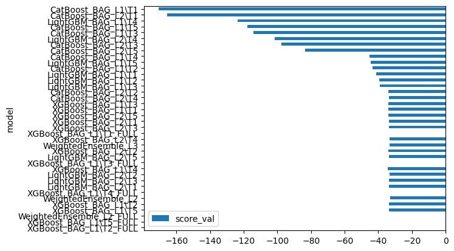

```python
predictor_new_hpo_wd.leaderboard(train, silent=True).plot(kind='barh', y='score_val', x='model')
```

```python
# Create predictions from test dataset
predictions_new_hpo_wd = predictor_new_hpo_wd.predict(test)
predictions_new_hpo_wd.head()
```

```
0    18.446257
1     4.866887
2     3.727374
3     2.161255
4     1.916265
Name: count, dtype: float32
```

```python
# Describe the `predictions` series to see if there are any negative values
predictions_new_hpo_wd.describe()
```

```
count    6493.000000
mean      188.924088
std       172.221878
min       -21.183661
25%        47.002811
50%       147.168320
75%       280.035400
max       893.938782
Name: count, dtype: float64
```

```python
# How many negative values do we have?
print("Total predictions             :", len(predictions_new_hpo_wd))
print("Total non-negative predictios :", (predictions_new_hpo_wd >= 0).sum())
print("Total negative predictios     :", (predictions_new_hpo_wd < 0).sum())
```

```
Total predictions             : 6493
Total non-negative predictios : 6411
Total negative predictios     : 82
```

```python
# Remember to set all negative values to zero
# Set them to zero
predictions_new_hpo_wd[predictions_new_hpo_wd<0] = 0    # Only needed if prediction values < 0
```

```python
# Is the problem solved?
print("Total predictions             :", len(predictions_new_hpo_wd))
print("Total non-negative predictios :", (predictions_new_hpo_wd >= 0).sum())
print("Total negative predictios     :", (predictions_new_hpo_wd < 0).sum())
```

```
Total predictions             : 6493
Total non-negative predictios : 6493
Total negative predictios     : 0
```

```python
# Same submitting predictions
submission_new_hpo_wd = pd.read_csv("sampleSubmission.csv",parse_dates=["datetime"])
submission_new_hpo_wd["count"] = predictions_new_hpo_wd
submission_new_hpo_wd.to_csv("submission_new_hpo_wd.csv", index=False)
```

```python
submission_new_hpo_wd
```

|  | datetime | count |
| --- | --- | --- |
| 0 | 2011-01-20 00:00:00 | 18.446257 |
| 1 | 2011-01-20 01:00:00 | 4.866887 |
| 2 | 2011-01-20 02:00:00 | 3.727374 |
| 3 | 2011-01-20 03:00:00 | 2.161255 |
| 4 | 2011-01-20 04:00:00 | 1.916265 |
| ... | ... | ... |
| 6488 | 2012-12-31 19:00:00 | 248.449539 |
| 6489 | 2012-12-31 20:00:00 | 160.364349 |
| 6490 | 2012-12-31 21:00:00 | 118.344162 |
| 6491 | 2012-12-31 22:00:00 | 83.264267 |
| 6492 | 2012-12-31 23:00:00 | 35.164745 |

6493 rows × 2 columns

```python
!kaggle competitions submit -c bike-sharing-demand -f submission_new_hpo_wd.csv -m "new features with hyperparameters2"
```

```
Successfully submitted to Bike Sharing Demand
```

```
  4%|4         | 8.00k/194k [00:00<00:03, 59.9kB/s]
```

```python
!kaggle competitions submissions -c bike-sharing-demand | tail -n +1 | head -n 6
```

```
fileName                     date                 description                         status    publicScore  privateScore
---------------------------  -------------------  ----------------------------------  --------  -----------  ------------
submission_new_hpo_wd.csv    2023-06-01 07:19:43  new features with hyperparameters2  complete  0.51866      0.51866
submission_new_hpo.csv       2023-05-30 21:26:39  new features with hyperparameters   complete  0.54626      0.54626
submission_new_features.csv  2023-05-29 09:01:21  new features                        complete  0.46416      0.46416
submission.csv               2023-05-28 08:17:53  first raw submission                complete  1.80912      1.80912
```

## Step 7: Write a Report

### Refer to the markdown file for the full report

### Creating plots and table for report

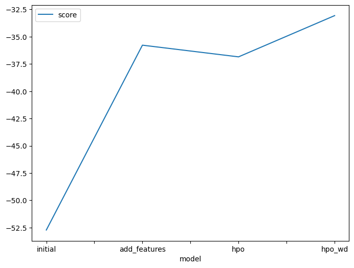

```python
# Taking the top model score from each training run and creating a line plot to show improvement
# You can create these in the notebook and save them to PNG or use some other tool (e.g. google sheets, excel)
fig = pd.DataFrame(
    {
        "model": ["initial", "add_features", "hpo", "hpo_wd" ],
        "score": [-52.722403, -35.780141, -36.850900, -33.070803]
    }
).plot(x="model", y="score", figsize=(8, 6)).get_figure()
fig.savefig('model_train_score.png')
```

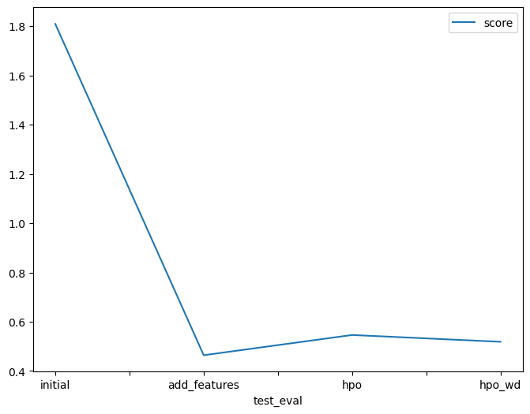

```python
# Take the 3 kaggle scores and creating a line plot to show improvement
fig = pd.DataFrame(
    {
        "test_eval": ["initial", "add_features", "hpo", "hpo_wd"],
        "score": [1.80912, 0.46416, 0.54626, 0.51866]
    }
).plot(x="test_eval", y="score", figsize=(8, 6)).get_figure()
fig.savefig('model_test_score.png')
```

### Hyperparameter table

```python
# The 3 hyperparameters we tuned with the kaggle score as the result
hytb=pd.DataFrame({
    "model": ["initial", "add_features", "hpo", "hpo_wd"],
    "hpo1": ['default_vals', 'default_vals', 'time_limit=12*600', 'time_limit=12*600' ],
    "hpo2": ['default_vals', 'Categorical features:[season, weather, workingday, holiday]', 'Categorical:[season, weather, workingday, holiday]', 'Categorical:[+ weekday]' ],
    "hpo3": ['default_vals;\r\nWeightedEnsemble_L3  -52.722403', 'default_vals;\r\nWeightedEnsemble_L3  -35.780141',
             "tabular autogluon: {'CAT','GBM','XGB'}\r\nWeightedEnsemble_L3: -36.850900",
            "tabular autogluon: {'CAT','GBM','XGB'}\r\nWeightedEnsemble_L2: -33.070803" ],
    "score": [ 1.80912, 0.46416, 0.54626,  0.51866 ]
})
hytb
```

|  | model | hpo1 | hpo2 | hpo3 | score |
| --- | --- | --- | --- | --- | --- |
| 0 | initial | default_vals | default_vals | default_vals;\r\nWeightedEnsemble_L3 -52.722403 | 1.80912 |
| 1 | add_features | default_vals | Categorical features:[season, weather, working... | default_vals;\r\nWeightedEnsemble_L3 -35.780141 | 0.46416 |
| 2 | hpo | time_limit=12*600 | Categorical:[season, weather, workingday, holi... | tabular autogluon: {'CAT','GBM','XGB'}\r\nWeig... | 0.54626 |
| 3 | hpo_wd | time_limit=12*600 | Categorical:[+ weekday] | tabular autogluon: {'CAT','GBM','XGB'}\r\nWeig... | 0.51866 |

```python
print(hytb.to_markdown())
```

```
|    | model        | hpo1              | hpo2                                                        | hpo3                                   |   score |
|---:|:-------------|:------------------|:------------------------------------------------------------|:---------------------------------------|--------:|
|  0 | initial      | default_vals      | default_vals                                                | default_vals;                          | 1.80912 |
|    |              |                   |                                                             | WeightedEnsemble_L3  -52.722403        |         |
|  1 | add_features | default_vals      | Categorical features:[season, weather, workingday, holiday] | default_vals;                          | 0.46416 |
|    |              |                   |                                                             | WeightedEnsemble_L3  -35.780141        |         |
|  2 | hpo          | time_limit=12*600 | Categorical:[season, weather, workingday, holiday]          | tabular autogluon: {'CAT','GBM','XGB'} | 0.54626 |
|    |              |                   |                                                             | WeightedEnsemble_L3: -36.850900        |         |
|  3 | hpo_wd       | time_limit=12*600 | Categorical:[+ weekday]                                     | tabular autogluon: {'CAT','GBM','XGB'} | 0.51866 |
|    |              |                   |                                                             | WeightedEnsemble_L2: -33.070803        |         |
```